# Motivation

Die Untersuchung von Kostentransparenz ist aus ökonomischer Sicht besonders spannend, da sie Einblicke in das Zusammenspiel von Marktverhalten, Preiswahrnehmung und Konsumentenvertrauen ermöglicht. In klassischen Märkten gilt Information als asymmetrisch verteilt - insbesondere Kostenstrukturen bleiben für Konsument:innen meist verborgen. Wenn Unternehmen jedoch freiwillig ihre Produktionskosten offenlegen, entsteht eine neue Form der Marktkommunikation, die sowohl auf das Kaufverhalten als auch auf die Markenbindung Einfluss nehmen kann.

In diesem Projekt beschäftigen Sie sich mit der ökonomischen Wirkung unterschiedlicher Formen von Kostentransparenz, darunter produktbezogene Einzelkosten-Offenlegung im Point-of-Sale oder auch verbal vermittelte Transparenz in Kombination mit Vertrauensmessung. Ziel ist es, zu untersuchen, wie sich diese Varianten auf Zahlungsbereitschaft, Vertrauen und wahrgenommene Preisfairness auswirken.

Kern dieser Ausarbeitung ist die Frage, inwiefern Kostentransparenz eine rationale Kaufentscheidung unterstützt oder über emotionale Mechanismen - etwa durch erhöhte Markenattraktivität - wirkt. Für die Analyse greifen Sie auf ein breites Methodenrepertoire zurück, das ökonomische Modellierung mit experimenteller Verhaltensforschung verbindet, und leisten so einen Beitrag zum besseren Verständnis moderner Konsumentenentscheidungen in transparenten Märkten. Für ihre Analyse verwenden Sie die Daten der folgenden Ausarbeitung:

**Mohan, B., Buell, R. W., & John, L. K. (2020). Lifting the veil: The benefits of cost transparency. Marketing Science, 39(6), 1105-1121.**

# Aufbau der Studie

1. Lesen Sie sich den folgenden Text zum Hintergrund und Aufbau der Studie durch und beantworten Sie nachfolgende Fragen dazu:

Der Ausgangspunkt der betrachteten Untersuchung war ein reales Ereignis: Ein Online-Händler stellte im Dezember 2013 ein hochwertiges Lederportemonnaie zum Verkauf. Einige Wochen später wurde auf den Produktseiten eine Infografik zur Kostenzusammensetzung ergänzt, allerdings versehentlich nur bei drei von fünf Farbvarianten. Obwohl der Händler diesen Fehler nicht beabsichtigte, entstand daraus ein sogenanntes natürliches Experiment, also eine reale Vergleichssituation mit kontrollierbaren Unterschieden. Die Verkäufe konnten analysiert werden, um zu überprüfen, ob die Offenlegung der Produktionskosten einen Einfluss auf das Kaufverhalten hatte.

Dieses natürliche Experiment lieferte erste Hinweise darauf, dass Kostentransparenz wirkt - und war damit die Basis für zwei gezielte Experimente im Labor, die Sie sich in diesem Projekt genauer anschauen sollen. Beide Laborexperimente knüpfen an die reale Ausgangslage an - gehen aber unterschiedliche Forschungsfragen an:

Experiment 1: In einem realitätsnahen Online-Setting wurde untersucht, ob Konsument:innen anders entscheiden, wenn sie Informationen zu Produktionskosten sehen. Hierbei sahen die Teilnehmer:innen eine Produktseite für einen Rucksack von Everlane - entweder mit oder ohne Kostenaufstellung (vgl. Abbildung 1: Kostentransparenz Infografik im Anhang). Zusätzlich wurde ein Vergleichsprodukt von J. Crew gezeigt (ohne Hinweise zur Kostenzusammensetzung). Die Teilnehmer:innen mussten entscheiden, von welchem Anbieter sie lieber einen Gutschein erhalten würden. Das Ziel der Forscher war es zu messen, ob Konsument:innen bei mehr Transparenz auch eher kaufen, folglich sich für diesen Gutschein entscheiden.

Experiment 2: Nachdem Experiment 1 zeigte, dass es einen Effekt der Kostentransparenz gibt, stellt sich die psychologische Anschlussfrage, warum es diesen Effekt gibt und wie dieser festzumachen ist. So sahen die Teilnehmer:innen im 2. Experiment ein fiktives Produkt - eine Schokoladentafel. In der Kontrollgruppe wurden nur übliche Produktinfos gezeigt. In der Treatmentgruppe gab es zusätzlich eine detaillierte Kostenaufstellung (vgl. Abbildung 2: Design der Schokoladenverpackung ohne und mit Kostentransparenz im Anhang). Im Anschluss wurden Vertrauen in die Marke und Kaufbereitschaft durch einen Fragebogen abgefragt. So sollte herausgefunden werden, ob Vertrauen der zentrale psychologische Mechanismus für die Kaufentscheidung der Kund:innen ist.

Beantworten Sie nun folgende Fragen:

1. Welches reale Ereignis war der Auslöser der Forschung?
2. Welche konkrete Verhaltensfrage steht im Mittelpunkt von Experiment 1 - Was wollten die Forscher:innen direkt am Kaufverhalten testen?
3. Welcher psychologische Faktor steht im Zentrum von Experiment 2 - und wie hängt er mit dem Kaufverhalten zusammen?

**Welches reale Ereignis war der Auslöser der Forschung?**

Das reale Ereignis, das den Ausgangspunkt der Forschung bildete, war ein Versehen eines Online-Händlers, der im Dezember 2013 die Kostenzusammensetzung eines hochwertigen Lederportemonnaies veröffentlichen wollte. Allerdings wurde die Infografik versehentlich nur bei drei von fünf Farbvarianten angezeigt. Dadurch entstand unbeabsichtigt ein sogenanntes natürliches Experiment – also eine reale Vergleichssituation, bei der einige Produkte mit, andere ohne Kostentransparenz verkauft wurden. Diese Situation ermöglichte es den Forschern, den Einfluss von Kostentransparenz auf das tatsächliche Kaufverhalten zu analysieren.

**Welche konkrete Verhaltensfrage steht im Mittelpunkt von Experiment 1 - Was wollten die Forscher:innen direkt am Kaufverhalten testen?**

Im Mittelpunkt von Experiment 1 steht die konkrete Verhaltensfrage, ob Konsument:innen sich anders entscheiden – insbesondere eher für ein Produkt bzw. einen Gutschein entscheiden – wenn ihnen eine transparente Kostenaufstellung vorliegt. Ziel war es, zu messen, ob Kostentransparenz das Vertrauen stärkt und dadurch direkt zu einer höheren Kaufwahrscheinlichkeit führt.

**Welcher psychologische Faktor steht im Zentrum von Experiment 2 - und wie hängt er mit dem Kaufverhalten zusammen?**

Experiment 2 geht über die Verhaltensbeobachtung hinaus und untersucht den psychologischen Mechanismus hinter dem Effekt der Kostentransparenz. Im Zentrum steht Vertrauen in die Marke als potenziell entscheidender Faktor. Es wurde überprüft, ob eine transparente Darstellung der Produktionskosten das Markenvertrauen stärkt und ob dieses gesteigerte Vertrauen wiederum die Kaufbereitschaft der Konsument:innen positiv beeinflusst.

Nachdem Sie nun die grundlegende Forschungsidee und Zielsetzung der beiden Experimente kennengelernt haben, befassen wir uns im nächsten Schritt vertiefend mit Experiment 1. Ziel ist es, den genauen Aufbau, sowie das konkrete Verhalten der Teilnehmer:innen besser zu verstehen.

2. Lesen Sie sich den folgenden Text zum Aufbau des ersten Experiments durch und beantworten Sie anschließend Fragen dazu:

Cost transparency refers to the disclosure of the costs to produce a good or provide a service. Although cost transparency is a strategy traditionally employed in the context of supplier-firm relationships, wherein the two-way sharing of cost information between parties facilitates collaboration on cost reduction measures, we investigate its effects within the context of consumer-firm relationships. Information on the costs associated with providing goods and services is rarely shared with consumers, but we provide evidence of when and why voluntarily doing so can increase consumers’ purchase interest. Specifically, building on the psychology of disclosure and trust, we posit that cost transparency, insofar as it represents an act of intimate disclosure, fosters trust. In turn, we propose that this heightened trust increases consumers’ willingness to purchase from the transparent firm. In the sections that follow, we discuss our central predictions and highlight alternative accounts. Then, we present experiments, conducted in the lab and in the field, that document the main effects of cost transparency, its underlying psychological drivers, and conditions that moderate its effects.

This first experiment explores how cost transparency influences consumer preferences in an online shopping context. The study was designed as a between-subjects randomized experiment using an incentive-compatible setup, meaning participants made real choices with the possibility of receiving a tangible reward. A total of 509 U.S.-based participants were recruited through Amazon Mechanical Turk (MTurk). Each participant was randomly assigned to one of two experimental conditions:

- Cost Transparency Condition: Participants were shown a simulated product page for a backpack sold by the retailer Everlane. This page included a cost breakdown infographic, listing the production costs such as materials, labor, transport, and duties, with a clearly stated total cost.
- Control Condition: Participants saw the same backpack from Everlane but without any cost information. In both conditions, participants also saw a comparable backpack from J. Crew, which does not practice cost transparency.

Participants were instructed to view both product pages and then asked which company they would prefer to receive a $50 gift card from. Their response served as the main behavioral outcome, representing a choice between the transparent vs. non-transparent retailer. To ensure accurate interpretation of the presented information, a comprehension check followed the main choice question. Participants were also asked for demographic information such as age, gender, income, and education, to allow for potential control variables in later analysis.

Beantworten Sie nun folgende Fragen:

1. Wie viele Personen nahmen final an dem Experiment teil?
2. Worin bestand der Unterschied zwischen der Transparenzbedingung und der Kontrollbedingung?
3. Welche Anreizstruktur wurde verwendet, um die Entscheidung der Teilnehmenden realistisch zu gestalten?
4. Wie unterschieden sich die beiden gezeigten Onlinehändler im Experiment?
5. Warum wurde im Anschluss an die Entscheidungsfrage ein Verständnischeck durchgeführt?
6. In der Beschreibung des Experiments wird von “between-subjects randomized experiment using an incentive-compatible setup” gesprochen. Was versteht man hierunter im Detail?

*Hinweis:* Für die Beantwortung der letzten Frage können Sie [diesen Artikel (Seite 1-5)](https://www.researchgate.net/publication/268269783_Incentives_in_Experiments_A_Theoretical_Analysis) als Grundlage verwenden.

**Wie viele Personen nahmen final an dem Experiment teil?**

Insgesamt nahmen 509 Personen an dem Experiment teil, die über Amazon Mechanical Turk (MTurk) rekrutiert wurden. MTurk ist eine Crowdsourcing-Plattform, die es Forschenden ermöglicht, schnell und kosteneffizient auf eine große und vielfältige Teilnehmergruppe zuzugreifen.

**Worin bestand der Unterschied zwischen der Transparenzbedingung und der Kontrollbedingung**

Im Experiment wurden den Teilnehmenden zwei Produktseiten für Rucksäcke gezeigt: eine von der Marke Everlane und eine von J. Crew. Der zentrale Unterschied zwischen den experimentellen Bedingungen lag in der Darstellung der Everlane-Seite. Der Rucksack von J. Crew wurde in beiden Bedingungen unverändert und ohne Kostentransparenz gezeigt. In der Transparenzbedingung wurde den Personen eine Infografik präsentiert, die eine detaillierte Aufschlüsselung der Produktionskosten enthielt – darunter Material-, Arbeits-, Transport- und Zollkosten sowie die Gesamtkosten des Everlane-Rucksackes. In der Kontrollbedingung hingegen sahen die Teilnehmenden dieselbe Produktseite, jedoch ohne jegliche Informationen zu den Herstellungskosten vom Everlane-Rucksack.

**Welche Anreizstruktur wurde verwendet, um die Entscheidung der Teilnehmenden realistisch zu gestalten?**

Um die Entscheidung der Teilnehmenden möglichst realitätsnah zu gestalten, wurde ein Setup verwendet, in welchem sich die Teilnehmer:innen für eine von zwei Optionen entscheiden mussten – konkret sollten sie angeben, von welchem der beiden Anbieter (Everlane oder J. Crew) sie lieber einen 50-Dollar-Geschenkgutschein erhalten würden. Dies sorgte dafür, dass die Entscheidung nicht nur hypothetisch war, sondern mit einem potenziellen realen Nutzen verbunden war. Dadurch wurde das Entscheidungsverhalten authentischer und besser messbar.

**Wie unterschieden sich die beiden gezeigten Onlinehändler im Experiment?**

Die beiden Onlinehändler unterschieden sich im Experiment hinsichtlich ihrer Transparenz über Produktionskosten. Everlane präsentierte sich in einer der Versuchsbedingungen als transparenter Anbieter, indem es auf der Produktseite des Rucksacks eine detaillierte Kostenaufstellung zeigte (Transparenzbedingung). J. Crew hingegen fungierte in beiden Bedingungen als Vergleichsanbieter ohne Kostentransparenz – dort wurden keine Informationen über die Zusammensetzung der Produktionskosten angegeben.

**Warum wurde im Anschluss an die Entscheidungsfrage ein Verständnischeck durchgeführt?**

Der Verständnischeck wurde durchgeführt, um sicherzustellen, dass die Teilnehmenden die präsentierten Informationen – insbesondere die Darstellung der Produktionskosten bei Everlane – korrekt wahrgenommen und verstanden haben. Nur wenn die Teilnehmenden die Unterschiede zwischen den Bedingungen nachvollziehen konnten, ist ihre Entscheidung zwischen Everlane und J. Crew aussagekräftig und belastbar. Der Verständnischeck dient somit der Qualitätssicherung der Daten und stellt sicher, dass beobachtete Effekte tatsächlich auf die Manipulation (Kostentransparenz) zurückzuführen sind und nicht auf Missverständnisse oder Unaufmerksamkeit.

**In der Beschreibung des Experiments wird von “between-subjects randomized experiment using an incentive-compatible setup” gesprochen. Was versteht man hierunter im Detail?**

Ein “between-subjects randomized experiment” bedeutet, dass die Teilnehmenden zufällig einer von zwei Bedingungen zugewiesen wurden – entweder der Transparenzbedingung (mit Kostenaufstellung) oder der Kontrollbedingung (ohne Kostenaufstellung). Jede Person nahm nur an einer Bedingung teil, sodass direkte Vergleiche zwischen Gruppen möglich sind, ohne dass sich Entscheidungen durch Mehrfachteilnahme gegenseitig beeinflussen.

Das **“incentive-compatible setup”** stellt sicher, dass die Entscheidungen der Teilnehmenden ihre wahren Präferenzen widerspiegeln. Um dies zu erreichen, wurde ein realer Anreiz geboten: Die Teilnehmenden mussten angeben, von welchem Anbieter (Everlane oder J. Crew) sie lieber einen 50-Dollar-Geschenkgutschein erhalten würden. Diese Entscheidung war nicht nur hypothetisch, sondern mit einer tatsächlichen Belohnung verbunden, wodurch die Teilnehmenden motiviert waren, ihre echte Präferenz anzugeben.

Ein solches Setup beruht auf dem Prinzip der **Anreizkompatibilität**, das in der experimentellen Wirtschaftsforschung sicherstellt, dass es für die Teilnehmenden am vorteilhaftesten ist, ehrlich zu antworten. Um mögliche Verzerrungen durch sogenannte **Komplementaritätseffekte** (wie Wohlstandseinflüsse oder Bündelungseffekte) zu vermeiden, wurde nur eine einzige Entscheidung relevant für die Auszahlung gemacht – ein Ansatz, der dem **Random Decision Selection (RDS)-Mechanismus** entspricht. Dieser Mechanismus verhindert, dass Entscheidungen durch andere Wahlmöglichkeiten oder potenzielle Auszahlungen beeinflusst werden, und erhöht so die Validität der Ergebnisse.

# Daten

## Datenimport und -aufbereitung

Die Daten, die Sie für die nachfolgenden Analysen verwenden, wurden zu Replikationszwecken von den Autoren der Studie zur Verfügung gestellt und können hier heruntergeladen werden:

**Bhavya Mohan, Ryan W. Buell, Leslie K. John (2020) Lifting the Veil: The Benefits of Cost Transparency. Marketing Science 39(6):1105-1121. mksc.2019.1200.sm1.pdf**

Wir haben die Daten für Sie heruntergeladen und im Unterordner mit dem Namen `Daten` bereitgestellt. Für ihre Analyse werden die Dateien `Experiment1.csv` und `Experiment2.csv` genutzt. Für die Zusatzaufgabe ist die Datei `Experiment3.csv` relevant.

3. Lesen Sie den Datensatz `Experiment1.csv` aus dem Unterordner `Daten` in R ein. Nennen Sie den Datensatz in R `daten_exp1`.

Im Datensatz sind unterschiedliche Variablen enthalten. Weiterhin habe wir Ihnen ein Readme mit den Beschreibungen zu den Variablen bereitgestellt. Nutzen Sie dieses und den Text aus Aufgabe 2, um die Variablen zu beschreiben.

### Beschreibung des Datensatzes zu Experiment 1: Kostentransparenz und Kaufpräferenzen

Der Datensatz zu Experiment 1 umfasst insgesamt 509 Beobachtungen – also Teilnehmende, die im Rahmen eines zwischen Versuchspersonen randomisierten Experiments befragt wurden.

Die zentrale Variable `treatment` (`0 = Kontrollgruppe`, `1 = Transparenzbedingung`) zeigt, ob eine Person die Everlane-Produktseite mit oder ohne Kostenaufstellung gesehen hat. Die Variable `everlane` (`1 = Everlane-Gutschein gewählt`, `0 = J. Crew`) ist die abhängige Verhaltensvariable, also die gemessene Kaufpräferenz der Teilnehmenden.

Zur Überprüfung der Datenqualität gibt die Variable `passed` an, ob die Teilnehmenden den Verständnischeck bestanden haben (1 = bestanden, 0 = nicht bestanden), und `email_provided` zeigt, ob sie eine E-Mail-Adresse für den potenziellen Geschenkgutschein hinterlassen haben (1 = E-Mail angegeben, 0 = keine Angabe) – beides wichtige Indikatoren für Engagement und Gültigkeit der Antworten.

Demografische Merkmale wie `female` (1 = weiblich), `age` (Alter in Jahren), `educ` (Bildungsniveau, 1 = niedriger bis 5 = postgradual) und `income` (monatliches Einkommen in zwölf Kategorien) erlauben differenzierte Analysen, z.B. ob bestimmte Personengruppen stärker auf Kostentransparenz reagieren..

## Deskriptive Analyse

Sie sollten sich im ersten Schritt einen Überblick über ihre Daten verschaffen.

4. Auf Basis des Datensatzes `daten_exp1` aus Aufgabe 3 erstellen Sie eine deskriptive Tabelle mit der Anzahl an Beobachtungen, den Mittelwerten, der Standardabweichungen, dem Median, sowie den Minima und Maxima für alle in `daten_exp1` enthaltenen Variablen.

Beschreiben und interpretieren Sie ihre Tabelle. Gehen Sie insbesondere auf die Verteilungen der einzelnen Variablen ein. Was fällt hier besonders auf.

Deskriptive Statistiken der Variablen – Experiment 1

Übersicht über Anzahl (N), Mittelwert, Standardabweichung sowie Median, Minimum und Maximum

|  | N | Mittelwert | Standardabw. | Median | Min | Max |
| --- | --- | --- | --- | --- | --- | --- |
| `Everlane gewählt` | 509 | 0.63 | 0.48 | 1 | 0 | 1 |
| `Verständnischeck bestanden` | 509 | 0.77 | 0.42 | 1 | 0 | 1 |
| `E-Mail angegeben` | 509 | 0.56 | 0.50 | 1 | 0 | 1 |
| `Weiblich` | 509 | 0.49 | 0.50 | 0 | 0 | 1 |
| `treatment` | 509 | 0.50 | 0.50 | 0 | 0 | 1 |
| `Alter` | 505 | 37.59 | 11.74 | 35 | 18 | 81 |
| `Bildung` | 505 | 3.76 | 0.84 | 4 | 1 | 5 |
| `Einkommen` | 505 | 7.58 | 2.43 | 8 | 1 | 12 |

### Deskriptive Ergebnisse zu den Variablen - Experiment 1

Die deskriptive Tabelle bietet eine Übersicht über die Variablen des Datensatzes `daten_exp1` von Experiment 1, aggregiert über alle Teilnehmenden unabhängig von ihrer Gruppenzugehörigkeit. Insgesamt liegen für die binären Variablen Daten von über 509 Personen vor und für die metrischen Daten von 505, was auf eine gute Datenqualität und geringe Ausfallraten hindeutet.

**Analyse der Variablen**

Die demografischen Merkmale der Stichprobe zeigen eine ausgewogene und gut durchmischte Zusammensetzung. Das durchschnittliche `Alter` der Teilnehmenden liegt bei etwa 37,6 Jahren (SD = 11,74), mit einer Spannweite von 18 bis 81 Jahren. Das `Bildungsniveau` ist insgesamt hoch: Der Mittelwert liegt bei 3,76 auf einer Skala von 1 (= niedrig) bis 5 (= postgradual), was auf eine eher akademisch geprägte Stichprobe schließen lässt. Auch das `Einkommen` ist relativ hoch angesiedelt (M = 7,58, SD = 2,43), auf einer Skala von 1 bis 12. Diese Werte deuten auf eine tendenziell einkommensstarke Teilnehmendengruppe hin.

Der Anteil weiblicher Teilnehmender beträgt 49%, was auf eine nahezu ausgewogene `Geschlechterverteilung` schließen lässt. Auch die Verteilung der `Treatment-Zuweisung` ist mit einem Mittelwert von 0,50 exakt balanciert, was ein starkes Indiz für eine erfolgreiche Randomisierung zwischen Kontroll- und Transparenzgruppe darstellt.

Besonders interessant sind die Verhaltensindikatoren: 63% der Teilnehmenden entschieden sich für den `Everlane-Gutschein` – ein Wert, der ohne Gruppendifferenzierung interpretiert werden muss, aber dennoch eine deutliche Präferenz für den Anbieter signalisiert. 77% bestanden den `Verständnischeck`, was zeigt, dass der Großteil der Teilnehmenden die zentralen Informationen des Experiments korrekt wahrgenommen und verarbeitet hat. Die Bereitschaft zur Angabe einer `E-Mail-Adresse` lag bei 56% – ein moderat hoher Wert, der auf eine gewisse Offenheit gegenüber weiterem Kontakt oder Folgestudien schließen lässt. Darüber hinaus war auch die Bereitschaft, persönliche Daten (`E-Mail-Adresse`) zu hinterlassen, in der Transparenzgruppe leicht erhöht (59% gegenüber 53% in der Kontrollgruppe). Obwohl dieser Unterschied kleiner ausfällt, könnte er als weiteres Signal für ein gestärktes Vertrauen in den Anbieter interpretiert werden.

Insgesamt zeigt die deskriptive Analyse ein konsistentes Bild: Die Stichprobe ist hinsichtlich zentraler Merkmale gut ausbalanciert, mit soliden Werten bei `Alter`, `Bildung` und `Einkommen`. Da in der vorliegenden Tabelle keine Gruppentrennung vorgenommen wurde, können keine direkten Aussagen über Effekte des `Treatments` gemacht werden. Dennoch bildet diese Tabelle eine wichtige Grundlage, um ein Gefühl für die Zusammensetzung und Tendenzen im Datensatz zu bekommen.

5. Im Datensatz `daten_exp1` gibt es Variablen für die keine Beobachtungen vorhanden sind.
- Gegeben ihrer Variablenbeschreibung in Aufgabe 3:
  - Macht es Sinn die Beobachtungen aus dem Datensatz zu entfernen, wenn für bestimmte Variablen keine Werte vorhanden sind?
  - Wenn ja, warum?
  - Wie viele Beobachtungen entfernen Sie dadurch aus ihrem Datensatz?

Entfernen Sie nun alle Beobachtungen (d.h. gesamte Zeilen aus dem Datensatz), bei denen für mindestens eine der erhobenen Variablen kein Wert vorliegt, da unvollständige Daten für die Analyse nicht berücksichtigt werden sollen.

Untersuchen Sie weiterhin, ob sich die Teilnehmer, die die Webseite mit der Kostentransparenz gesehen haben (Treatmentgruppe), systematisch von jenen unterscheiden, die die Kontrollversion gesehen haben. Auch wenn es sich um ein Experiment handelt, bei dem die Zuteilung zu den Gruppen zufällig erfolgt ist, sollten Sie dennoch prüfen, ob es unbeabsichtigte (systematische) Unterschiede zwischen den Gruppen gibt. Erstellen Sie hierfür eine Balancing-Tabelle, in der Sie die Mittelwerte von Alter (age), Geschlecht (female), Einkommensstufe (income) und Bildungsniveau (educ) zwischen den beiden Gruppen vergleichen, die Differenzen berechnen und mithilfe von T-Tests prüfen, ob diese Unterschiede statistisch signifikant sind.

- Beschreiben und interpretieren Sie ihre Tabelle.
  - Was fällt Ihnen in Bezug auf die p-Werte auf?
  - Was müssten Sie bei einer weiteren Regressionsanalyse berücksichtigen?

*Hinweis:* Die beiden Gruppen, die Sie in der Balancing Tabelle betrachten sollen, können aus den Werten (1 und 0) der Variable `treatment` abgeleitet werden.

**Macht es Sinn die Beobachtungen aus dem Datensatz zu entfernen, wenn für bestimmte Variablen keine Werte vorhanden sind? Wenn ja, warum?**

Ja, das Entfernen der Beobachtungen mit fehlenden Werten ist sinnvoll. Wenn in einem experimentellen Datensatz zentrale Variablen wie Alter, Bildung oder Einkommen nur teilweise erhoben wurden, führt dies zu einer verzerrten Stichprobe. Zwar liegt eine zufällige Zuteilung in Treatment- und Kontrollgruppe vor, doch durch das selektive Fehlen einzelner Werte wird diese Vergleichbarkeit beeinträchtigt. Infolgedessen kann es zu einer unrealistischen Darstellung der Gruppenunterschiede kommen, was die Interpretation der Effekte verzerren und die Aussagekraft statistischer Tests mindern würde. Um valide und konsistente Ergebnisse zu gewährleisten, ist es daher gerechtfertigt, unvollständige Beobachtungen aus der Analyse auszuschließen.

Balancing-Tabelle zwischen Treatment- und Kontrollgruppe - Experiment 1

Vergleich zentraler Merkmale nach experimenteller Bedingung: Mittelwerte, Differenz und Signifikanztest (t-Test)

|  | Kontrollgruppe | Treatmentgruppe | Differenz | p-Wert |
| --- | --- | --- | --- | --- |
| Balancing-Vergleich |  |  |  |  |
| `Alter` | 37.913 | 37.273 | −0.640 | 0.541 |
| `Weiblich` | 0.488 | 0.490 | 0.002 | 0.964 |
| `Einkommen` | 7.405 | 7.763 | 0.358 | 0.098 |
| `Bildung` | 3.734 | 3.794 | 0.060 | 0.418 |

p-Werte basieren auf zweiseitigen t-Tests; Unterschiede sind bei p < 0,05 statistisch signifikant.

### Balancing-Analyse zu Experiment 1

Die Balancing-Tabelle bietet einen Überblick über die Verteilung zentraler demografischer Merkmale – `Alter`, `Geschlecht`, `Einkommen` und `Bildung` – zwischen der Kontrollgruppe (`treatment = 0`) und der Transparenzgruppe (`treatment = 1`). Ziel dieser Analyse ist es zu prüfen, ob sich die beiden Gruppen vor der Intervention systematisch unterscheiden, was die Annahme einer erfolgreichen Randomisierung untermauern oder infrage stellen würde.

**Balancing-Check zwischen Kontroll- und Transparenzgruppe**

Die Ergebnisse zeigen, dass die Mittelwerte der beiden Gruppen in allen vier Merkmalen sehr ähnlich sind. Das durchschnittliche `Alter` liegt bei etwa 37 Jahren, der Anteil weiblicher Teilnehmender bei rund 49 %, das mittlere `Einkommen` bei etwa 7,5 Punkten auf einer Skala von 1 bis 12 und das durchschnittliche `Bildungsniveau` bei rund 3,7 auf einer Skala von 1 bis 5. Die Differenzen zwischen den Gruppen sind minimal – die größte Abweichung zeigt sich beim `Alter` mit 0,640 Punkten Differenz, gefolgt von `Einkommen` (0,358), `Bildung` (0,060) und `Geschlecht` (0,002).

Entscheidend für die Interpretation sind die zugehörigen `p-Werte`, die anzeigen, ob die Unterschiede zwischen den Gruppen statistisch signifikant sind. Alle p-Werte liegen deutlich über dem gängigen Signifikanzniveau von 0,05 (`Alter`: p = 0.541, `Geschlecht`: p = 0.964, `Einkommen`: p = 0.098, `Bildung`: p = 0.418), was bedeutet, dass keiner der beobachteten Unterschiede signifikant ist. Die Ergebnisse sprechen somit klar für eine erfolgreiche Randomisierung: Die Gruppen unterscheiden sich in ihren Ausgangsmerkmalen nicht systematisch. Wäre hingegen einer dieser Unterschiede signifikant gewesen, hätte dies darauf hingedeutet, dass die Randomisierung nicht vollständig geglückt ist – was die Aussagekraft der Ergebnisse geschwächt und die Interpretation möglicher `Treatment-Effekte` erschwert hätte. Die Gleichverteilung zentraler Merkmale ist eine zentrale Voraussetzung für die interne Validität eines Experiments, da nur so sichergestellt werden kann, dass beobachtete Unterschiede im Verhalten – wie etwa in der Wahl des `Everlane-Gutscheins` – kausal auf die `Treatmentbedingung` zurückgeführt werden können.

Im Kontext der in Aufgabe 4 beschriebenen deskriptiven Ergebnisse bestätigt die Balancing-Tabelle das Bild einer gut kontrollierten Experimentalumgebung. Die Gruppen sind nicht nur nahezu gleich groß, sondern auch hinsichtlich ihrer demografischen Zusammensetzung vergleichbar. Damit wird eine wichtige Grundlage geschaffen, um den beobachteten Effekt – den deutlich höheren Anteil von `Everlane-Wahlen` in der Transparenzgruppe – nicht durch verzerrende Drittvariablen erklären zu müssen.

**Was müsste bei einer weiteren Regressionsanalyse berücksichtigt werden?**

Auch wenn die Randomisierung grundsätzlich geglückt ist, kann es aus methodischer Sicht dennoch sinnvoll sein, zentrale demografische Merkmale als `Kontrollvariablen` in die Regressionsanalyse aufzunehmen. Für nachfolgende Regressionsanalysen bedeutet das: Obwohl keine signifikanten Unterschiede in den Ausgangsmerkmalen bestehen, empfiehlt es sich, demografische Variablen wie `Alter`, `Einkommen` und `Bildung` zu kontrollieren. Erstens können diese Variablen zusätzliche Varianz aufklären und die Präzision der Schätzungen verbessern. Zweitens zeigt insbesondere der p-Wert für `Einkommen` (p = 0.098), dass ein möglicher latenter Einfluss nicht vollständig auszuschließen ist. Die Berücksichtigung dieser Merkmale erhöht somit sowohl die Robustheit als auch die Glaubwürdigkeit der späteren Ergebnisse.

Nachdem Sie sich in den vorangegangenen Aufgaben bereits mit der Verteilung der Daten und den Unterschieden zwischen den einzelnen Gruppen auseinandergesetzt haben, geht es nun um eine explorative Betrachtung von Zusammenhängen zwischen den zentralen Variablen im Datensatz.

6. In dieser Aufgabe führen Sie eine Korrelationsanalyse durch, um herauszufinden, ob und wie stark einzelne Merkmale - wie Alter, Bildung, Einkommen oder Geschlecht - mit der Treatment-Zugehörigkeit sowie der Entscheidung für die Everlane-Gutscheinkarte zusammenhängen.

Wählen Sie die folgenden Variablen aus dem Datensatz `daten_exp1` aus:

- treatment
- everlane
- age
- income
- educ
- female

Berechnen Sie die Korrelationsmatrix dieser Variablen. Visualisieren Sie die Matrix (als Tabelle oder Grafik), in der die Korrelationskoeffizienten und deren Stärke farblich dargestellt sind.

Beschreiben und interpretieren Sie ihre Tabelle/Grafik. Gehen Sie hierbei auch auf folgende Fragen ein:

- Was bedeutet ein positiver Zusammenhang (Korrelation) zwischen `treatment` und `everlane` im Kontext der Hypothese, dass Kostentransparenz die Entscheidung für Everlane beeinflusst?
- Warum kann eine Korrelation auf einen Zusammenhang hinweisen, aber nicht ausreichen, um einen kausalen Effekt nachzuweisen - selbst wenn wir wissen, dass `treatment` im Experiment zufällig zugewiesen wurde?
- Was nützt ihnen eine Korrelationsmatrix im Vergleich zu einem einfachen Mittelwertvergleich zwischen den Gruppen?

*Hinweis:* Für die Darstellung der Korrelationsmatrix können Sie z.B. das Paket corrplot verwenden.

**Korrelationsmatrix für Variablen von Experiment 1**

Die Werte zeigen die Korrelation zwischen den Variablen an (−1 = starke negative, +1 = starke positive Korrelation)

|  | Treatment | Everlane gewählt | Alter | Bildung | Einkommen |
| --- | --- | --- | --- | --- | --- |
| Everlane gewählt | 0.158 |  |  |  |  |
| Alter | −0.027 | −0.053 |  |  |  |
| Bildung | 0.036 | −0.009 | −0.018 |  |  |
| Einkommen | 0.074 | −0.043 | −0.021 | 0.187 |  |
| Weiblich | 0.002 | 0.090 | 0.058 | −0.037 | 0.031 |

[figure not shown]

### Korrelationsmatrix: Zusammenhang zwischen Treatment, Wahlverhalten und demografischen Merkmalen

Nachdem in den vorangegangenen Aufgaben bereits die Verteilung der Daten sowie Unterschiede zwischen Kontroll- und `Treatmentgruppe` betrachtet wurden, dient die vorliegende Korrelationsanalyse einer Untersuchung zentraler Zusammenhänge im Datensatz `daten_exp1` von Experiment 1. Ziel ist es, zu prüfen, ob und in welcher Stärke demografische Merkmale wie `Alter`, `Bildung`, `Einkommen` und `Geschlecht` mit der `Treatment-Zugehörigkeit` sowie der Entscheidung für die `Everlane-Gutscheinkarte` in Zusammenhang stehen.

**Ergebnisse der Korrelationsmatrix**

Die Korrelationsmatrix zeigt insgesamt nur schwache Zusammenhänge zwischen den untersuchten Variablen. Der auffälligste Wert ist die positive Korrelation zwischen `treatment` und `everlane` (r = 0.158). Dieser Zusammenhang stützt die zentrale Hypothese des Experiments: Kostentransparenz wirkt sich positiv auf die Präferenz für `Everlane` aus. Zwar ist der Wert niedrig, dennoch zeigt er in die erwartete Richtung.

Andere Zusammenhänge – etwa zwischen `Bildung` und `Einkommen` (r = 0.187) – sind theoretisch plausibel, aber in Bezug auf die experimentelle Manipulation weniger bedeutsam. Die Korrelationen zwischen `treatment` und den übrigen Merkmalen wie `Alter`, `Geschlecht` oder `Bildung` liegen alle nahe bei null. Dies ist ein wichtiges Ergebnis, da es erneut bestätigt, dass die Randomisierung erfolgreich war und keine systematischen Unterschiede in den Ausgangsmerkmalen zwischen den Gruppen bestehen – ein zentrales Ziel in einem between-subjects Design wie in diesem Experiment.

**Einordnung der Korrelation zwischen Treatment und Everlane-Wahl**

Die positive Korrelation zwischen der Transparenzbedingung (`treatment`) und der Entscheidung für den `Everlane-Gutschein` (`everlane`) deutet darauf hin, dass Teilnehmende, die die Infografik mit den Produktionskosten sahen, sich häufiger für `Everlane` entschieden. Dieser Zusammenhang ist konsistent mit der zentralen Hypothese des Experiments, wonach Kostentransparenz das Vertrauen in die Preisgestaltung stärkt und dadurch die Kaufentscheidung beeinflusst.

**Warum eine Korrelation kein Beleg für Kausalität ist**

Die positive Korrelation zwischen `treatment` und `Everlane-Wahl` deutet darauf hin, dass die Transparenzbedingung das Entscheidungsverhalten beeinflusst haben könnte – ein Ergebnis, das die zentrale Hypothese des Experiments stützt. Dennoch liefert eine Korrelation allein keinen kausalen Beweis, da sie lediglich das gemeinsame Auftreten zweier Variablen abbildet. Auch bei zufälliger Zuteilung muss erst durch kontrollierte Regressionsanalysen und die Berücksichtigung des `Verständnisschecks` geprüft werden, ob die Transparenz tatsächlich ursächlich für die Präferenz zugunsten `Everlane` war.

**Vorteile der Korrelationsmatrix im Vergleich zum Mittelwertvergleich**

Während Mittelwertvergleiche – wie sie in den vorherigen Aufgaben zur Balancierung und Effektschätzung eingesetzt wurden – gezielt Unterschiede zwischen Gruppen darstellen, bietet die Korrelationsmatrix eine breitere Perspektive. Sie erlaubt, alle paarweisen Zusammenhänge im Datensatz gleichzeitig zu betrachten – insbesondere zwischen `Treatment`, `Entscheidung` und den soziodemografischen Merkmalen. Gerade im Kontext dieses Experiments ist das wertvoll: Die Matrix zeigt etwa, dass `Alter`, `Geschlecht` oder `Bildung` nicht mit der `Treatmentzugehörigkeit` zusammenhängen – ein klares Signal für die erfolgreiche Randomisierung. Gleichzeitig lassen sich mögliche Störfaktoren frühzeitig identifizieren und für weiterführende Regressionsanalysen einplanen. Damit ergänzt die Korrelationsanalyse die Mittelwertvergleiche sinnvoll und stärkt die Validität und Belastbarkeit der Befunde.

Insgesamt liefert die Korrelationsmatrix wichtige Hinweise auf die Plausibilität der experimentellen Ergebnisse. Der schwach positive Zusammenhang zwischen Transparenzbedingung und `Everlane-Wahl` stimmt mit der Hypothese überein, dass Kostentransparenz das Verhalten beeinflusst. Gleichzeitig zeigt die Matrix, dass demografische Merkmale nicht mit der Bedingungszuweisung zusammenhängen – ein weiteres Indiz für die Gültigkeit der Randomisierung.

7. In Aufgabe 1 und 2 haben Sie gelesen, dass den Teilnehmern ein Angebot gemacht wurde, eine Everlane-Gutscheinkarte anzunehmen. Erzeugen Sie eine geeignete Grafik, die den durchschnittlichen Anteil der angenommenen Angebote (d.h. den Anteil, in dem die Everlane-Karte gewählt wurde) getrennt für die Treatment- und die Kontrollgruppe darstellt. Fügen Sie in der Grafik zusätzlich den Standardfehler der Mittelwerte ein. Führen Sie einen T-Test durch, um zu prüfen, ob der Unterschied im Mittelwert zwischen der Treatment- und Kontrollgruppe statistisch signifikant ist, und geben Sie das Testergebnis (den p-Wert) deutlich sichtbar in der Grafik an. Achten Sie dabei auf eine verständliche Beschriftung Ihrer Grafik sowie auf einen aussagekräftigen Titel.

Beschreiben und interpretieren Sie ihre Grafik. Gehen Sie insbesondere auf folgende Fragen ein:

- Welche Aussage lässt sich auf Basis des durchgeführten T-Tests treffen?
- Welche der in den vorherigen Aufgaben (vgl. Aufgabe 4 und 5) analysierten Faktoren könnten dazu beigetragen haben, dass ein signifikanter Unterschied im Anteil angenommener Everlane-Angebote zwischen Treatment- und Kontrollgruppe beobachtet wird?

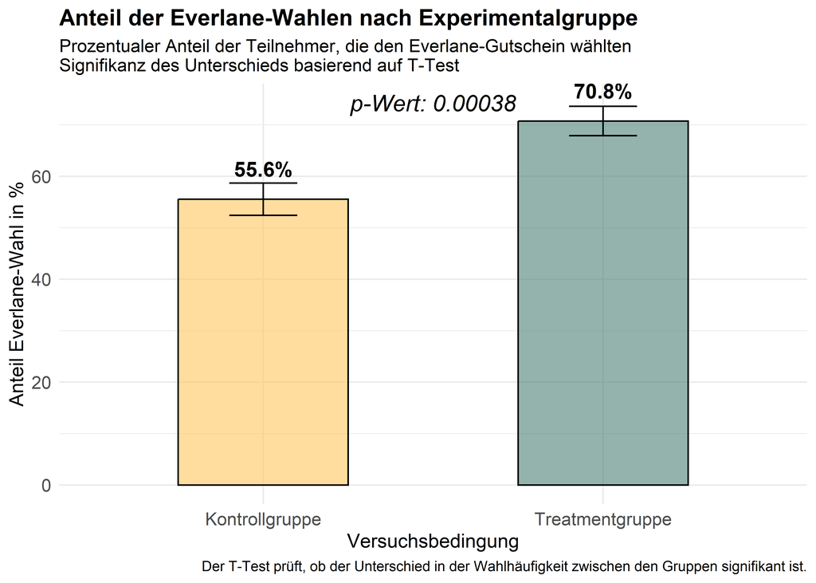

### Wirkung der Treatment-Bedingung: Analyse der Gutscheinwahl mit T-Test

Die Grafik zeigt den prozentualen Anteil der Teilnehmer:innen, die sich in zwei unterschiedlichen Experimentalbedingungen für einen Gutschein des Anbieters Everlane entschieden haben. Auf der X-Achse sind die beiden Versuchsbedingungen abgebildet: `Kontrollgruppe` (ohne Kostentransparenz) und `Treatmentgruppe` (mit Kostentransparenz). Die Y-Achse stellt den Anteil der `Everlane-Wahlen` in Prozent dar. Über jedem Balken befindet sich der jeweilige exakte Prozentwert, ergänzt um Standardfehlerbalken.

**Ergebnisse des Diagramms**

In der `Kontrollgruppe` entschieden sich 55,6% der Personen für den `Everlane-Gutschein`. In der `Treatmentgruppe` waren es 70,8%. Dieser Unterschied wird durch den in der Grafik ausgewiesenen `p-Wert` von 0.00038 untermauert, der deutlich über den Balken dargestellt ist. Der `p-Wert` stammt aus einem T-Test, der prüft, ob der Unterschied in der Wahl des `Everlane-Gutscheins` zwischen den beiden Gruppen statistisch signifikant ist. Ein Wert von `p < 0.001` bedeutet, dass die Wahrscheinlichkeit, diesen Unterschied zufällig zu beobachten, unter 0.1% liegt. Somit kann mit hoher Sicherheit geschlossen werden, dass die beobachtete Differenz nicht zufällig, sondern auf die Einflussbedingung (Kostentransparenz) zurückzuführen ist.

**Interpretation im Kontext von Experiment 1**

Die Grafik belegt anschaulich, dass Kostentransparenz das Konsumentenverhalten signifikant beeinflusst. Die höhere Wahlrate des Gutscheins in der `Treatmentgruppe` deutet darauf hin, dass offen gelegte Produktionskosten die Vertrauenswürdigkeit und Attraktivität des Anbieters steigern. Die Maßnahme der Kostentransparenz scheint also ein wirkungsvoller psychologischer Hebel zu sein, um Kaufentscheidungen positiv zu beeinflussen.

**Faktoren, die zum signifikanten Unterschied in der Everlane-Wahl beigetragen haben könnten**

Ein zentraler Aspekt ist das durch Kostentransparenz gestärkte Vertrauen in den Anbieter. In der `Treatmentgruppe` wurde offen dargelegt, wie sich der Preis des Produkts zusammensetzt – mit einem Herstellungspreis von 36,35 US-Dollar bei einem Verkaufspreis von 68 US-Dollar. Viele Teilnehmer:innen dürften diese Preisdifferenz als fair wahrgenommen haben. Die Offenlegung der Produktionskosten könnte dabei als Zeichen von Ehrlichkeit und Integrität interpretiert worden sein.

Ein weiterer wichtiger Faktor ist die gesteigerte Informationsverarbeitung in der `Treatmentgruppe`. Dies zeigt sich in der deutlich höheren Bestehensrate beim `Verständnischeck`: 92% der Teilnehmer:innen in der `Treatmentgruppe` beantworteten die Verständnisfragen korrekt, verglichen mit 63% in der `Kontrollgruppe`. Dies deutet auf ein höheres kognitives Engagement hin, das sich auf die Entscheidung ausgewirkt haben könnte.

Auch die Bereitschaft zur Angabe persönlicher Daten (z.B. `E-Mail-Adresse`) war in der `Treatmentgruppe` leicht erhöht (59% vs. 53%). Dies könnte ebenfalls ein Hinweis auf gestärktes Vertrauen sein.

Insgesamt legt die Analyse nahe, dass Kostentransparenz das Vertrauen und die Entscheidungsbereitschaft erhöht, wobei die Unterschiede klar der `Treatmentbedingung` zugeordnet werden können..

In den vorherigen Aufgaben des Projekts haben Sie sich bereits intensiv mit dem Experiment 1 auseinandergesetzt, in dem untersucht wurde, ob und wie die Offenlegung von Produktionskosten - also Kostentransparenz - das Konsumverhalten beeinflusst. Es wurde gezeigt: Wenn Konsument:innen transparent mitgeteilt wird, wie sich die Kosten eines Produkts zusammensetzen, steigt ihre Bereitschaft, bei dem entsprechend transparenten Unternehmen einzukaufen.

Diese Ergebnisse legen nahe, dass die Offenlegung sensibler Unternehmensinformationen (wie Produktionskosten) das Vertrauen der Konsument:innen in das Unternehmen stärkt und sie somit eher zu einem Kauf motiviert.

Doch was genau ist der psychologische Mechanismus hinter dieser Wirkung? Ist es tatsächlich das Vertrauen in das Unternehmen, das durch die Offenlegung sensibler Informationen gestärkt wird - und in der Folge die Kaufbereitschaft erhöht?

Um genau diese Frage zu beantworten, führen die Autoren ein weiteres Experiment durch, das den vermuteten psychologischen Vermittlungsmechanismus des Vertrauens genauer untersucht. Dabei wurde geprüft, ob Vertrauen tatsächlich als Mediator zwischen Kostentransparenz und Kaufinteresse wirkt. Hierzu wurde ein kontrolliertes Online-Experiment mit über 600 Teilnehmer:innen durchgeführt. Die Teilnehmenden wurden zufällig einer von zwei Bedingungen zugewiesen:

- In der **Kostentransparenz-Gruppe** (Treatment) wurde zusätzlich eine detaillierte Aufschlüsselung der Produktionskosten angegeben. Diese beinhaltete die einzelnen Kostenkomponenten (z.B. Kakaobutter, Verpackung, Arbeitskosten) sowie die Gesamtkosten der Schokoladentafel (vgl. Abbildung 2 im Anhang).
- In der **Kontrollgruppe** sahen die Teilnehmer die Verpackung einer fiktiven Schokoladenmarke namens „Cocoa Passion“. Diese enthielt nur die üblichen Informationen wie Zutaten, Nährwerte und eine Produktbeschreibung.

Ziel war es, zu untersuchen, ob die Offenlegung dieser sensiblen Informationen das Vertrauen der Konsument:innen in die Marke stärkt - und ob dieses Vertrauen wiederum die Kaufbereitschaft beeinflusst. In den nächsten Aufgaben werden Sie diese Studie genauer beleuchten, analysieren und evaluieren, ob sich die Hypothese empirisch bestätigen lässt.

8. Lesen Sie die Daten des zweiten Experiments (`Experiment2.csv`) in R ein. Nennen Sie den Datensatz `daten_exp2`. Benennen Sie die Variable `cost` in `treatment` um.

Untersuchen Sie, ob sich die Teilnehmer, die die Verpackung mit transparenter Kosteninformation gesehen haben, systematisch von jenen unterscheiden, die nur die Kontrollversion gesehen haben.

Erstellen Sie hierfür eine Balancing-Tabelle, in der Sie die Mittelwerte von Alter (age), Geschlecht (female), Einkommensstufe (income), Bildungsniveau (educ), Vertrauen (trust) und Kaufbereitschaft (wtb) zwischen den beiden Gruppen vergleichen, die Differenzen berechnen und mithilfe von T-Tests prüfen, ob diese Unterschiede statistisch signifikant sind. Nehmen Sie weiterhin die Anzahl an Beobachtungen in der Treatment- und in der Kontrollgruppe in ihre Tabelle mit auf.

Beschreiben und interpretieren Sie ihre Tabelle. Gehen Sie dabei insbesondere auf folgende Fragen ein:

- Was versteht man unter der Variable `wtb`?
- Was lässt sich aus der Größen der Stichprobe ableiten?
- Wo könnte es bei einer Regression (oder einem sonstigen Vergleich der Gruppen) zu Problemen kommen und was wären mögliche Auswirkungen?

*Hinweis:* Für die Beschreibung der `wtb` können Sie das bereitgestellte Readme nutzen.

Balancing-Tabelle zwischen Treatment- und Kontrollgruppe – Experiment 2

Vergleich zentraler Merkmale nach experimenteller Bedingung: Mittelwerte, Differenz und Signifikanztest (t-Test)

|  | Kontrollgruppe | Treatmentgruppe | Differenz | p-Wert |
| --- | --- | --- | --- | --- |
| `Alter` | 36.282 | 34.063 | −2.219 | 0.016 |
| `Weiblich` | 0.422 | 0.477 | 0.055 | 0.178 |
| `Einkommen` | 6.960 | 6.793 | −0.167 | 0.380 |
| `Bildung` | 3.515 | 3.573 | 0.058 | 0.399 |
| `Vertrauen` | 4.821 | 5.293 | 0.473 | 0.000 |
| `Kaufbereitschaft (wtb)` | 3.741 | 4.273 | 0.532 | 0.001 |

Anzahl Beobachtungen: Kontrollgruppe = 301, Treatmentgruppe = 300

### Balancing-Analyse zu Experiment 2

**Interpretation der Balancing-Tabelle**

Die vorliegende Tabelle stellt den Vergleich zentraler Merkmale zwischen `Kontrollgruppe` und `Treatment-Gruppe` des zweiten Experiments dar. In diesem Experiment sahen die Teilnehmer:innen eine fiktive Schokoladentafel – entweder mit einer klassischen Verpackung (`Kontrollgruppe`) oder mit einer zusätzlichen Infografik zur Kostenzusammensetzung (`Treatmentgruppe`). Im Anschluss wurden sie gebeten, Fragen zu ihrem `Vertrauen` in die Marke sowie ihrer `Kaufbereitschaft` zu beantworten.

Berücksichtigt werden soziodemografische Variablen (`Alter`, `Geschlecht`, `Einkommen`, `Bildung`) sowie die psychologischen Zielgrößen Vertrauen („`trust`“) und `Kaufbereitschaft („wtb“)`. Für jede Variable werden die Mittelwerte beider Gruppen, deren Differenz (`Treatmentgruppe` minus `Kontrollgruppe`) sowie die entsprechenden p-Werte aus zweiseitigen t-Tests berichtet. Am Tabellenende sind die Gruppengrößen aufgeführt.

**Was versteht man unter der Variable `wtb`?**

Die Variable `wtb` steht für die Kaufbereitschaft („willingness to buy“). Sie erfasst, wie wahrscheinlich es ist, dass Teilnehmer:innen das im Experiment gezeigte Produkt (eine Schokolade) kaufen würden. Die Messung erfolgt auf einer siebenstufigen Likert-Skala von 1 (überhaupt nicht wahrscheinlich) bis 7 (sehr wahrscheinlich). Diese Variable bildet somit eine zentrale Zielgröße im Experiment, da sie direkt das potenzielle Konsumverhalten widerspiegelt.

9. In ihrem Datensatz gibt es einige Beobachtungen ohne vorhandene Werte. Behalten Sie nur die Beobachtungen bei denen vollständige Werte vorliegen. Erzeugen Sie eine geeignete Grafik, welche den durchschnittlichen Anteil der ‘Kaufbereitschaft’ im zweiten Experiment für die Treatment- und Kontrollgruppe darstellt.

Die Grafik soll:

- die Mittelwerte der Kaufbereitschaft für beide Gruppen zeigen,
- die zugehörigen Standardfehler als Fehlerbalken visualisieren und
- das Ergebnis des T-Tests, der die Mittelwertdifferenz prüft, direkt in die Grafik integrieren.

Beschreiben und interpretieren Sie ihre Grafik.

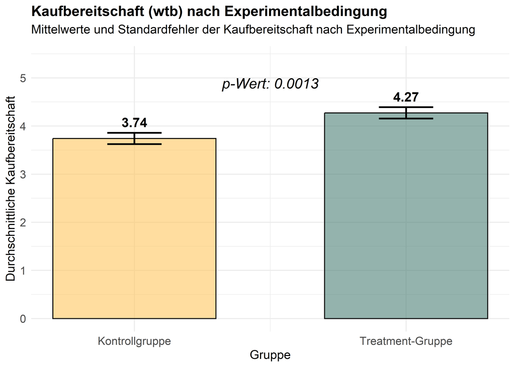

## Einfluss von Kostentransparenz auf die Kaufbereitschaft: Ergebnisse aus Experiment 2

**Beschreibung und Interpretation**

Die dargestellte Grafik visualisiert die durchschnittliche `Kaufbereitschaft` der Teilnehmer:innen im zweiten Experiment, getrennt nach Experimentalbedingung. Die zentrale Zielgröße, die sogenannte „willingness to buy“ (`wtb`), wurde auf einer siebenstufigen Skala erfasst, wobei höhere Werte eine stärkere `Kaufabsicht` anzeigen. Der Mittelwert der `Kaufbereitschaft` beträgt in der `Kontrollgruppe` 3.74, während er in der `Treatment-Gruppe`, die mit transparenter Information über die Produktionskosten der Schokolade konfrontiert wurde, bei 4.27 liegt.

Die Balken geben die Mittelwerte beider Gruppen wieder, ergänzt um Fehlerbalken, die die Standardfehler des Mittelwerts repräsentieren. Diese sind in beiden Gruppen relativ klein, was auf eine hohe Stabilität der Mittelwertschätzungen schließen lässt. Die Differenz zwischen den beiden Gruppen beträgt 0.53 Skalenpunkte und ist damit auch praktisch relevant.

Zur statistischen Absicherung dieser beobachteten Differenz wurde ein zweiseitiger T-Test durchgeführt, dessen Ergebnis in der Grafik explizit angegeben ist. Der `p-Wert` beträgt 0.0013 und liegt damit deutlich unter dem gängigen Signifikanzniveau von 0.05. Dies bedeutet, dass die beobachtete Differenz mit hoher Wahrscheinlichkeit nicht durch Zufall zustande gekommen ist. Vielmehr spricht das Ergebnis dafür, dass die Offenlegung der Produktionskosten – als Maßnahme der Kostentransparenz – einen signifikanten positiven Einfluss auf die `Kaufbereitschaft` der Konsument:innen hat.

Die grafische Darstellung unterstreicht damit nicht nur die statistische Signifikanz des Effekts, sondern erlaubt auch eine intuitive Einschätzung seiner Stärke. Während die `Kontrollgruppe` nur eine moderate Kaufneigung zeigt, lässt sich in der `Treatment-Gruppe` eine klar höhere Bereitschaft zum Kauf feststellen. Dies stützt die theoretische Annahme, dass Transparenz das Vertrauen in ein Unternehmen stärkt und dadurch die Entscheidungsbereitschaft für einen Kauf erhöht.

Nachdem Sie nun die Differenzen in der Kaufabsicht zwischen der Treatment- und der Kontrollgruppe im zweiten Experiment überprüft und getestet haben, geht es im nächsten Schritt darum, den möglichen Mediator Vertrauen genauer zu untersuchen. Hierfür sollen Sie sich in einem ersten Schritt das Vertrauen der Personen allgemein anschauen, um einen Eindruck zu dieser wichtigen Variable zu bekommen. Dafür werden Personen anhand **hohem und niedrigem** Vertrauen und deren Kaufbereitschaft für das Produkt unterteilt.

10. Erstellen Sie eine oder mehrere geeignete Grafik(en), die den Zusammenhang zwischen Vertrauen (Trust) und der Kaufabsicht (WTB) **unabhängig** der beiden Treatment- und Kontrollgruppen darstellen. Achten Sie auf eine passende Darstellung der Informationen.

Die Grafik(en) sollen folgende Informationen enthalten:

- Unterteilen Sie ihre Daten in Personen mit `hohem` und `niedrigem` Vertrauen. Nutzen Sie für die Unterteilung den Median des Vertrauens in ihren Daten als Schwellenwert.
- Abhängig der Einstufungen in `hohes` und `niedriges` Vertrauen soll nun die durchschnittliche Kaufbereitschaft dargestellt werden. Hier soll die Grafik so dargestellt werden, dass auf der x-Achse das Vertrauensniveau (“hoch” und “niedrig”) und auf der y-Achse die entsprechende Kaufbereitschaft abgebildet wird.
- Berechnen Sie weiterhin die Mittelwerte der beiden Vertrauensgruppen und visualisieren diese in geeigneter Art und Weise in ihren Grafik(en).
- Führen Sie einen t-Test durch, um zu prüfen, ob die Mittelwertsunterschiede zwischen den beiden Vertrauensgruppen statistisch signifikant sind. Geben Sie den p-Wert in der Grafik an.

Beschreiben und interpretieren Sie ihre Grafik(en). Beantworten Sie insbesondere folgende Fragen:

- Welche Implikationen hat ein signifikanter Unterschied für die Rolle von Vertrauen auf Kaufentscheidungen?
- Wie stark unterscheidet sich die Kaufbereitschaft zwischen Personen mit hohem und niedrigem Vertrauen?
- Könnte auf Basis ihrer Darstellung Vertrauen als Mediator zwischen dem Treatment und der Kaufbereitschaft fungieren?

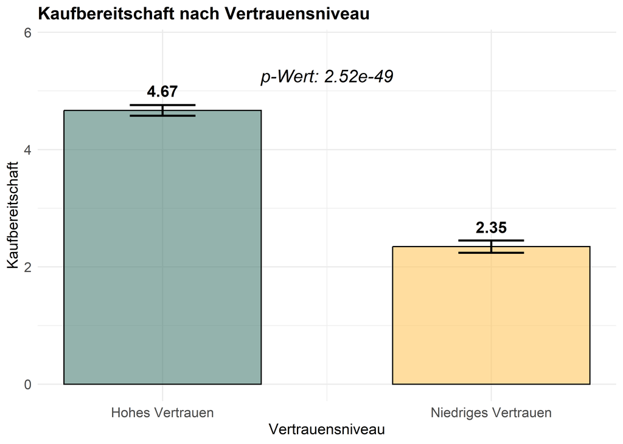

## Vertrauen als Schlüsselfaktor im Kaufverhalten?

**Interpretation der Grafik**

Die Balkengrafik zeigt den Zusammenhang zwischen dem `Vertrauensniveau` der Teilnehmenden und ihrer `Kaufbereitschaft` (`WTB` – “Willingness to Buy”) unabhängig von der `Treatment-` oder `Kontrollgruppe`. Die Variable „`Vertrauen`“ wurde in zwei Teile aufgeteilt, wobei der Median als Schwellenwert zur Einteilung in „niedriges Vertrauen“ und „hohes Vertrauen“ verwendet wurde.

Die Ergebnisse zeigen einen deutlichen Unterschied: Personen mit hohem `Vertrauen` weisen eine durchschnittliche `Kaufbereitschaft` von 4.67 auf der 7-Punkte-Skala auf, während die durchschnittliche `Kaufbereitschaft` in der Gruppe mit niedrigem `Vertrauen` nur 2.35 beträgt. Dieser Unterschied ist auch statistisch hoch signifikant (`p-Wert` < 0.001), wie durch den T-Test belegt. Die Standardfehler sind klein, was auf stabile Mittelwerte in beiden Gruppen hindeutet. Der visuelle Abstand zwischen den Balken unterstreicht die Stärke des Effekts.

Diese Analyse macht deutlich, dass `Vertrauen` nicht nur ein begleitender psychologischer Faktor ist, sondern eine zentrale Rolle in der Bewertung und Auswahl von Produkten spielt.

**Implikationen für die Rolle von Vertrauen in Kaufentscheidungen**

Die Ergebnisse legen nahe, dass `Vertrauen` einen entscheidenden Einfluss auf die Kaufentscheidung hat. Personen mit höherem `Vertrauen` sind deutlich eher bereit, das Produkt zu kaufen. Damit wird `Vertrauen` zu einem relevanten psychologischen Hebel, den Unternehmen gezielt ansprechen können – etwa durch Maßnahmen zur Erhöhung der Kostentransparenz oder durch glaubwürdige Markenkommunikation. Insofern ist `Vertrauen` nicht nur ein weiches Image-Merkmal, sondern ein konkreter Einflussfaktor auf das wirtschaftliche Verhalten der Konsument:innen.

**Ausmaß der Unterschiede in der Kaufbereitschaft zwischen Vertrauensgruppen**

Die Differenz in der `Kaufbereitschaft` beträgt 2.32 Punkte auf einer 7-Punkte-Skala. Dies entspricht einem substantiellen Unterschied, der auch aus inhaltlicher Sicht als stark zu bewerten ist. Die Höhe dieser Differenz zeigt, dass `Vertrauen` nicht nur eine statistisch signifikante, sondern auch eine praktisch bedeutsame Wirkung entfaltet. Personen mit hohem `Vertrauen` bewerten ihre Kaufabsicht beinahe doppelt so hoch wie Personen mit niedrigem `Vertrauen`.

**Potenzial von Vertrauen als Mediator zwischen Treatment und Kaufbereitschaft**

Die dargestellten Befunde deuten darauf hin, dass `Vertrauen` als vermittelnde Variable (Mediator) zwischen der experimentellen Bedingung (z.B. Kostentransparenz) und der `Kaufbereitschaft` fungieren könnte. Frühere Ergebnisse zeigten bereits, dass das `Vertrauen` durch die `Treatment-Bedingung` erhöht wurde. Nun wird belegt, dass `Vertrauen` wiederum stark mit der `Kaufbereitschaft` zusammenhängt. Damit sind zwei notwendige Bedingungen für Mediation erfüllt: erstens ein signifikanter Zusammenhang zwischen `Treatment` und `Vertrauen`, und zweitens ein signifikanter Zusammenhang zwischen `Vertrauen` und `Kaufbereitschaft`.

# Regressionsanalyse

Sie haben nun ihren Datensatz kennengelernt und es scheint so, als ob insbesondere Personen, welche transparente Kosten sehen, dazu neigen, das Produkt zu kaufen. Doch um ihre deskriptiven Analysen zu erhärten, wollen Sie im folgenden eine Analyse mittels Regressionen durchführen.

11. Betrachten Sie hier noch einmal das erste Experiment (`daten_exp1`). Führen Sie eine Regression durch, bei der Ihnen `everlane` als abhängige Variable dient. Als erklärende Variable nutzen Sie das `treatment`. Erstellen sie eine weitere Regression, die zusätzlich noch für die folgenden Variablen kontrolliert:
- Alter
- Bildungsstufe
- Einkommen
- Geschlecht

Stellen Sie die Regressionsergebnisse in einer Tabelle mit stargazer oder modelsummary dar!

Beschreiben und interpretieren Sie ihre Ergebnisse. Gehen Sie insbesondere auf folgende Fragen ein:

- Lässt sich der Effekt des Treatments auf die Entscheidung der Kunden kausal interpretieren?
- Ist es wichtig auf weitere Faktoren zu kontrollieren?
- Beziehen Sie sich hier auch auf die Ergebnisse aus Aufgabe 5.

**Regressionsergebnisse zur Everlane-Wahl – Erstes Experiment**

|  | *Dependent variable:* |  |
| --- | --- | --- |
|  | Abhängige Variable: Everlane gewählt |  |
|  | Regression | Regression |
|  | (1) | (2) |
| Treatment | 0.152*** | 0.155*** |
|  | (0.042) | (0.042) |
| Alter |  | -0.002 |
|  |  | (0.002) |
| Bildung |  | -0.001 |
|  |  | (0.026) |
| Einkommen |  | -0.012 |
|  |  | (0.009) |
| Weiblich |  | 0.091** |
|  |  | (0.042) |
| Constant | 0.556*** | 0.686*** |
|  | (0.030) | (0.132) |
| Observations | 505 | 505 |
| R<sup>2</sup> | 0.025 | 0.039 |
| Residual Std. Error | 0.477 (df = 503) | 0.476 (df = 499) |
| *Note:* | p<0.1; p<0.05; p<0.01 |  |
|  | Signifikanzniveaus: * p < 0.1; ** p < 0.05; *** p < 0.01 |  |

Die vorliegende Regressionsanalyse untersucht den Effekt der Anzeige transparenter Produktionskosten (`Treatment`) auf die Entscheidung von Teilnehmenden, das Produkt von „`Everlane`“ zu wählen. Im ersten Modell („Treatment Only“) wurde ausschließlich das `Treatment` als erklärende Variable berücksichtigt. Im zweiten Modell („Mit Kontrollen“) wurden zusätzlich `Alter`, `Bildungsniveau`, `Einkommen` und `Geschlecht` als Kontrollvariablen einbezogen.

In beiden Modellen zeigt sich ein signifikanter positiver Effekt des Treatments: Im Modell ohne Kontrollvariablen beträgt der geschätzte Effekt 0.152 (p < 0.001), Im Modell mit Kontrollvariablen liegt der Effekt bei 0.155 (p < 0.001). Personen, die die transparente Preisaufschlüsselung gesehen haben, entscheiden sich mit einer um etwa 15 Prozentpunkte höheren Wahrscheinlichkeit für das Unternehmen Everlane. Dieser Effekt bleibt auch nach Einbeziehung relevanter individueller Merkmale stabil. Unter den Kontrollvariablen ist lediglich das `Geschlecht` signifikant: Weibliche Teilnehmende haben eine um rund 9 Prozentpunkte höhere Wahrscheinlichkeit, Everlane zu wählen (p < 0.05).

Der Anstieg des Bestimmtheitsmaßes (R²) von 0.025 auf 0.039 zeigt, dass der Zugewinn an Erklärungskraft durch die Kontrollvariablen gering bleibt. Der zentrale Einflussfaktor ist und bleibt das `Treatment` selbst.

**Kausale Interpretation des Treatment-Effekts**

Da die Teilnehmenden im Rahmen eines kontrollierten Experiments zufällig den Gruppen zugewiesen wurden, können die beobachteten Effekte kausal interpretiert werden. Die Randomisierung stellt sicher, dass systematische Verzerrungen oder unbeobachtete Drittvariablen ausgeschlossen werden. Somit lässt sich mit hoher Sicherheit sagen, dass die transparente Offenlegung von Produktionskosten direkt zu einer höheren Wahrscheinlichkeit führt, bei Everlane zu kaufen.

**Relevanz zusätzlicher Kontrollvariablen**

Auch wenn das Experiment auf ein robustes Design setzt, kann die Einbeziehung von Kontrollvariablen zusätzliche Informationen liefern. In diesem Fall zeigen sich keine substanziellen Änderungen in der Größe oder Signifikanz des `Treatment`-Effekts. Dennoch ist die Signifikanz des Merkmals „`weiblich`“ ein Hinweis darauf, dass Geschlecht eine gewisse Rolle spielen könnte. Kontrollvariablen erhöhen die Präzision der Schätzungen und liefern einen differenzierteren Einblick – sind jedoch bei einem sauber randomisierten Experiment nicht zwingend erforderlich für die Schätzung des kausalen Effekts.

**Bezug zu Aufgabe 5 (Balancing-Tabelle)**

Die Ergebnisse der Balancing-Tabelle in Aufgabe 5 zeigten bereits, dass zwischen den Gruppen keine systematischen Unterschiede in den wichtigsten Ausgangsvariablen (`Alter`, `Bildung`, `Einkommen`, `Geschlecht`) bestanden. Dies stärkt die Validität des Randomisierungsprozesses und unterstützt die Annahme, dass das `Treatment` der einzige systematische Unterschied zwischen den Gruppen ist. Die Ergebnisse der Regressionsanalyse bestätigen diesen Befund: Die Wirkung des `Treatments` bleibt auch bei zusätzlicher Kontrolle konstant, was auf einen echten, robusten kausalen Zusammenhang hinweist.

Während die bisherigen Analysen zeigen, dass das Treatment einen Effekt hat, stellt sich nun die Frage, warum das so ist. Nun sollten Sie im weiteren Verlauf durch vertiefende Regressionsanalysen prüfen, ob dies auf das Vertrauen der Kunden zurückzuführen ist. Dazu betrachten Sie noch einmal den Datensatz zu Experiment 2 (`daten_exp2`) und untersuchen, ob das Treatment (Kunden sehen transparente Kostenstruktur) zu einer höheren Kaufabsicht führt, weil sie das Vertrauen der Konsumenten in das Unternehmen stärkt.

12. Schauen Sie sich den Einfluss der Kostentransparenz auf die Kaufabsicht in den folgenden zwei Regressionen genauer an und zeigen Sie ihre Ergebnisse nebeneinander:

**1. Regression:** Abhängige Variable ist die Kaufabsicht; die erklärende Variable ist das Treatment.

**2. Regression:** Wie in der 1. Regression, doch kontrollieren Sie hier zusätzlich auf die Variablen Alter, Einkommensniveau, Bildungsstufe und Geschlecht.

Stellen Sie die Regressionsergebnisse in einer Tabelle mit stargazer oder modelsummary dar!

Beschreiben und interpretieren Sie ihre Ergebnisse allgemein. Gehen Sie weiterhin auch speziell auf folgende Fragen ein:

- Sollten die Kontrollvariablen in ihrer zweiten Regression den Koeffizienten des Treatments ändern? Was würden Sie erwarten und warum? Nutzen Sie hierzu die Ergebnisse aus Aufgabe 8.
  - Vergleichen Sie die Regressionskoeffizienten der Treatment-Variable in der ersten und zweiten Regression. Gibt es hier einen signifikanten Unterschied in der Größe des Effekts?
- Bringt ihnen die Regression Vorteile gegenüber einer reinen Darstellung der Mittelwerte wie in Aufgabe 9?
- Ist der Effekt des Treatments auf die Kaufabsicht ihrer Ansicht nach kausal interpretierbar?
  - Welche Voraussetzungen müssen erfüllt sein, damit man diesen Regressionskoeffizienten als kausalen Effekt interpretieren kann?
  - Überlegen Sie sich, wie sich das Ergebnis verändern würde, wenn zusätzlich Vertrauen (trust) in das Modell aufgenommen wird. Würde sich der Effekt von `treatment` verändern? Warum oder warum nicht?

**Einfluss von Kostentransparenz auf Kaufabsicht (Experiment 2)**

|  | *Dependent variable:* |  |
| --- | --- | --- |
|  | Kaufabsicht (wtb) |  |
|  | Regression | Regression |
|  | (1) | (2) |
| Treatment | 0.532*** | 0.501*** |
|  | (0.165) | (0.166) |
| Alter |  | -0.013* |
|  |  | (0.007) |
| Einkommen |  | 0.023 |
|  |  | (0.036) |
| Bildung |  | 0.102 |
|  |  | (0.099) |
| Weiblich |  | -0.001 |
|  |  | (0.168) |
| Constant | 3.741*** | 3.702*** |
|  | (0.116) | (0.470) |
| Observations | 601 | 601 |
| R<sup>2</sup> | 0.017 | 0.025 |
| Residual Std. Error | 2.021 (df = 599) | 2.019 (df = 595) |
| *Note:* | p<0.1; p<0.05; p<0.01 |  |

Beschreiben und interpretieren Sie ihre Ergebnisse allgemein. Gehen Sie weiterhin auch speziell auf folgende Fragen ein:

- Sollten die Kontrollvariablen in ihrer zweiten Regression den Koeffizienten des Treatments ändern? Was würden Sie erwarten und warum? Nutzen Sie hierzu die Ergebnisse aus Aufgabe 8.
  - Vergleichen Sie die Regressionskoeffizienten der Treatment-Variable in der ersten und zweiten Regression. Gibt es hier einen signifikanten Unterschied in der Größe des Effekts?
- Bringt ihnen die Regression Vorteile gegenüber einer reinen Darstellung der Mittelwerte wie in Aufgabe 9?
- Ist der Effekt des Treatments auf die Kaufabsicht ihrer Ansicht nach kausal interpretierbar?
  - Welche Voraussetzungen müssen erfüllt sein, damit man diesen Regressionskoeffizienten als kausalen Effekt interpretieren kann?
  - Überlegen Sie sich, wie sich das Ergebnis verändern würde, wenn zusätzlich Vertrauen (trust) in das Modell aufgenommen wird. Würde sich der Effekt von `treatment` verändern? Warum oder warum nicht?

### Regressionsanalyse zur Wirkung von Kostentransparenz auf Kaufbereitschaft

**Beschreibung der Regressionstabelle**

Die Tabelle zeigt die Ergebnisse zweier linearer Regressionen zur Untersuchung des Einflusses von `Kostentransparenz` auf die `Kaufabsicht` im Rahmen von Experiment 2. In beiden Modellen ist die `Kaufabsicht` („wtb“) die abhängige Variable, gemessen auf einer siebenstufigen Likert-Skala.

Im ersten Modell wird ausschließlich das `Treatment` berücksichtigt – also ob Teilnehmer:innen eine Verpackung mit transparenter Kostenaufstellung gesehen haben. Der Effekt des `Treatments` ist mit einem Koeffizienten von 0.533 deutlich positiv und hoch signifikant (p < 0.01). Dies deutet darauf hin, dass die Offenlegung von Produktionskosten die `Kaufabsicht` im Durchschnitt um mehr als einen halben Skalenpunkt erhöht. Die erklärte Varianz liegt bei R² = 0.017 und ist damit noch relativ gering.

Im zweiten Modell werden zusätzlich `Alter`, `Einkommen`, `Bildung` und `Geschlecht` als Kontrollvariablen einbezogen. Der Effekt des `Treatments` bleibt auch hier signifikant und weitgehend stabil (0.501, p < 0.01), was auf die Robustheit des Effekts hinweist. Unter den Kontrollvariablen ist lediglich das Alter signifikant (p < 0.1): Ältere Personen zeigen tendenziell eine geringere `Kaufabsicht.` Die übrigen Variablen weisen keine signifikanten Effekte auf. Die erklärte Varianz steigt durch die zusätzlichen Prädiktoren leicht auf R² = 0.025.

**Interpretation der Regressionen**

Die Ergebnisse bestätigen, dass Kostentransparenz einen signifikanten und robusten Einfluss auf die `Kaufabsicht` hat. Dieser bleibt auch nach Kontrolle relevanter soziodemografischer Merkmale bestehen, was die interne Validität der Ergebnisse stärkt.

Der leichte Rückgang des `Treatment`-Koeffizienten von 0.533 auf 0.501 lässt vermuten, dass ein kleiner Teil des Effekts – insbesondere über die Variable `Alter` – erklärbar ist. Dennoch bleibt der Unterschied gering, was dafür spricht, dass der Effekt der Kostentransparenz weitgehend unabhängig von soziodemografischen Unterschieden wirkt.

Die nur geringe Zunahme der erklärten Varianz durch das zweite Modell verdeutlicht, dass die zusätzlich einbezogenen Kontrollvariablen nur einen begrenzten Beitrag zur Erklärung der `Kaufabsicht` leisten. Der wesentliche Einfluss geht somit weiterhin vom `Treatment` aus.

**Ändern die Kontrollvariablen in ihrer zweiten Regression den Koeffizienten des Treatments?**

Die Balancing-Tabelle zeigt, dass die Randomisierung insgesamt erfolgreich war: Für zentrale soziodemografische Merkmale wie `Geschlecht`, `Einkommen` und `Bildung` bestehen keine signifikanten Unterschiede zwischen Kontroll- und Treatmentgruppe. Lediglich beim Alter zeigt sich ein statistisch signifikanter Unterschied (p = 0.016), wobei die Treatmentgruppe im Schnitt rund 2,2 Jahre jünger ist. Dieser Unterschied ist zwar formal signifikant, dürfte inhaltlich jedoch nur einen geringen Einfluss auf die abhängige Variable haben – zumal auch in der Regressionsanalyse nur ein schwacher Zusammenhang zwischen `Alter` und `Kaufabsicht` erkennbar ist. Entsprechend wäre lediglich ein leichter Rückgang des Treatment-Koeffizienten in der zweiten Regression zu erwarten.

**Gibt es einen signifikanten Unterschied in der Größe des Effekts zwischen der ersten und zweiten Regression?**

In beiden Regressionsmodellen zeigt sich ein positiver und hoch signifikanter Effekt der `Kostentransparenz` auf die `Kaufabsicht.` Der Koeffizient sinkt von 0.533 im ersten Modell auf 0.501 im zweiten Modell, in dem `Alter`, `Einkommen`, `Bildung` und `Geschlecht` kontrolliert werden. Dieser Rückgang ist minimal, der Effekt bleibt signifikant. Es besteht somit kein signifikanter Unterschied zwischen den beiden Modellen – der Einfluss der `Kostentransparenz` ist robust gegenüber soziodemografischen Merkmalen.

**Welche Voraussetzungen müssen erfüllt sein, damit man diesen Regressionskoeffizienten als kausalen Effekt interpretieren kann?**

Damit ein Regressionskoeffizient als kausaler Effekt interpretiert werden kann, müssen bestimmte Voraussetzungen erfüllt sein. Zunächst ist eine erfolgreiche Randomisierung zentral: Nur wenn die Zuweisung zum `Treatment` zufällig erfolgt, kann sichergestellt werden, dass sich die Gruppen im Durchschnitt ausschließlich hinsichtlich des `Treatments` unterscheiden und alle anderen potenziellen Einflussfaktoren gleich verteilt sind. Dadurch werden systematische Unterschiede zwischen den Gruppen – sowohl in beobachteten als auch in unbeobachteten Variablen – weitgehend ausgeschlossen. Eine weitere Voraussetzung ist das Fehlen unbeobachteter Confounder, also Drittvariablen, die sowohl mit dem `Treatment` als auch mit der Zielvariable (in diesem Fall: `Kaufabsicht`) zusammenhängen könnten. Auch diese Bedingung wird durch eine gelungene Randomisierung weitgehend erfüllt.

**Ist der Effekt des Treatments auf die Kaufabsicht ihrer Ansicht nach kausal interpretierbar?**

Ja, unter den gegebenen Bedingungen lässt sich der Effekt unserer Ansicht nach als kausal interpretieren. Die Randomisierung war – wie die Balancing-Tabelle in Aufgabe 8 zeigt – erfolgreich: Es bestehen keine signifikanten Unterschiede in zentralen soziodemografischen Merkmalen zwischen den Gruppen, mit Ausnahme eines kleinen Unterschieds beim `Alter.` Dieser wird in der Regression kontrolliert und beeinflusst den Treatment-Effekt nur geringfügig. Hätte sich der Effekt des `Treatments` nach Einbezug der Kontrollvariablen deutlich verändert, könnte das auf eine Scheinkorrelation oder Moderation hinweisen. In der vorliegenden Analyse bleibt der Effekt jedoch nahezu unverändert, was für einen stabilen und kausal interpretierbaren Zusammenhang zwischen `Kostentransparenz` und `Kaufabsicht` spricht.

**Vorteile der Regression gegenüber einer reinen Darstellung der Mittelwerte wie in Aufgabe 9**

Die Regressionsanalyse bietet grundsätzlich eine deutlich präzisere und analytisch stärkere Möglichkeit, Zusammenhänge zwischen Variablen zu untersuchen als ein bloßer Mittelwertvergleich. Sie erlaubt nicht nur die Quantifizierung von Effekten, sondern auch die statistische Prüfung ihrer Signifikanz.

Der Mittelwertvergleich aus Aufgabe 9 zeigt anschaulich, dass die `Kaufbereitschaft` in der Treatmentgruppe (M = 4.27) höher ist als in der Kontrollgruppe (M = 3.74) und dieser Unterschied statistisch signifikant ist (p = 0.001). Dies liefert einen ersten Hinweis darauf, dass das `Treatment` wirkt – allerdings ohne Berücksichtigung möglicher Störfaktoren.

Die Regressionsanalyse hingegen ermöglicht es, zusätzliche Kovariaten wie `Alter`, `Einkommen`, `Bildung` und `Geschlecht` zu kontrollieren. Dadurch lässt sich gezielt prüfen, ob der beobachtete Unterschied tatsächlich auf das Treatment zurückzuführen ist oder ob er durch systematische Unterschiede zwischen den Gruppen beeinflusst wird. Die Regressionsmodelle zeigen, dass der Effekt der Kostentransparenz auch nach Kontrolle dieser Variablen bestehen bleibt – was die Aussagekraft und Robustheit des Effekts deutlich erhöht. Darüber hinaus erlaubt die Regression eine präzise Schätzung des Effekts in Skalenpunkten (hier: ca. +0.5 Punkte auf der 7er-Skala), ergänzt um Konfidenzintervalle, Signifikanztests und den erklärten Varianzanteil (R²).

**Überlegen Sie sich, wie sich das Ergebnis verändern würde, wenn zusätzlich Vertrauen (trust) in das Modell aufgenommen wird. Würde sich der Effekt von `treatment` verändern? Warum oder warum nicht?**

Wenn `Vertrauen` als zusätzliche Variable in das Regressionsmodell aufgenommen wird, ist zu erwarten, dass sich der Effekt des `Treatments` deutlich reduziert – möglicherweise wird er sogar insignifikant. Der Grund dafür liegt in der vermittelnden Rolle (Mediation), die `Vertrauen` in diesem Zusammenhang spielt.

Die Grafik aus Aufgabe 9 zeigt, dass Teilnehmer:innen mit hohem `Vertrauen` (mehrheitlich aus der Treatmentgruppe, olivgrün) eine deutlich höhere `Kaufbereitschaft` haben als solche mit niedrigem `Vertrauen.` Das legt nahe, dass das `Treatment` die `Kaufabsicht` nicht direkt, sondern über den Aufbau von `Vertrauen` beeinflusst. Wird `Vertrauen` ins Modell aufgenommen, „erklärt“ diese Variable dann einen großen Teil des ursprünglichen Effekts des Treatments.

In statistischer Hinsicht bedeutet die Rolle von `Vertrauen` als Mediator, dass der Effekt des `Treatments` auf die `Kaufabsicht` nicht ausschließlich direkt, sondern indirekt über `Vertrauen` wirkt. Das heißt: Das `Treatment` (die transparente Kostenaufstellung) führt zunächst zu einem Anstieg des `Vertrauens` in das Unternehmen – und dieses gesteigerte `Vertrauen` wiederum erhöht die `Kaufbereitschaft.` Wenn `Vertrauen` in das Regressionsmodell aufgenommen wird, „fängt“ es also einen Teil (oder sogar den Großteil) des ursprünglichen Treatment-Effekts ab. Der direkte Effekt des `Treatments` auf die `Kaufabsicht` wird dadurch geringer oder möglicherweise statistisch insignifikant – nicht weil das `Treatment` wirkungslos ist, sondern weil sein Effekt durch `Vertrauen` vermittelt wird.

Sie haben nun gesehen, dass es auch hier einen direkten Effekt des Treatments (transparente Kostenstrukur) auf die Kaufabsicht gibt. Doch um die dahinter liegenden Mechanismen zu verstehen, müssen Sie tiefer in psychologische Prozesse eintauchen. Experiment 2 zeigt dafür ein entsprechendes Design, um zu testen, ob Vertrauen als vermittelnder Mechanismus eine Rolle spielt. Im nächsten Schritt analysieren Sie nun selbst diese Beziehung mit theoretischen Modellen und Regressionsmethoden, um ein Gefühl dafür zu bekommen, wie sich direkte und indirekte Effekte voneinander unterscheiden.

13. Bevor Sie im nächsten Schritt ein konkretes DAG zu einem psychologischen Mediationsmechanismus erstellen, machen Sie sich zunächst mit den theoretischen Grundlagen von Directed Acyclic Graphs (DAGs) vertraut. DAGs (gerichtete azyklische Graphen) sind ein nützliches Werkzeug in der Kausalanalyse.

Beantworten Sie folgende theoretische Fragen zu DAGs:

- Wofür werden DAGs in der empirischen Forschung verwendet?
- Nennen und beschreiben Sie zwei zentrale Knotentypen in einem DAG: Confounder und Mediator.
- Worin besteht der zentrale Unterschied, ob Vertrauen als Kontrollvariable (Confounder) oder als Mediator behandelt wird - und warum ist Letzteres entscheidend für das Verständnis psychologischer Prozesse im vorliegenden Experiment?

**Verwendung von DAGs in der empirischen Forschung**

Directed Acyclic Graphs (DAGs) werden genutzt, um kausale Zusammenhänge zwischen Variablen grafisch darzustellen. Sie helfen, theoretische Annahmen über Ursache-Wirkungs-Beziehungen explizit zu machen und bieten eine Grundlage, um zu entscheiden, welche Variablen kontrolliert werden müssen, um Verzerrungen zu vermeiden. Besonders in der Kausalanalyse sind DAGs ein zentrales Hilfsmittel, um Scheinkorrelationen zu erkennen und valide Schätzstrategien zu entwickeln.

**Confounder und Mediator als zentrale Knotentypen**

Ein Confounder ist eine Variable, die sowohl das `Treatment` als auch die Zielvariable beeinflusst und dadurch eine Scheinkorrelation erzeugen kann, wenn sie nicht berücksichtigt wird. Ein Mediator liegt hingegen auf dem kausalen Pfad zwischen `Treatment` und Zielvariable. Er vermittelt den Effekt des `Treatments` weiter. Während der Confounder verzerrend wirkt, erklärt der Mediator einen Teil des Wirkmechanismus.

**Unterschiedliche Rolle von Vertrauen im Modell**

Ob `Vertrauen` als Confounder oder Mediator behandelt wird, ist entscheidend für die Interpretation des Effekts. Wird `Vertrauen` als Confounder kontrolliert, entfernt man den vermittelten Effekt aus der Analyse. Als Mediator hingegen erklärt `Vertrauen`, wie Kostentransparenz zur erhöhten `Kaufabsicht` führt. In der vorliegenden Studie ist `Vertrauen` plausibel als psychologischer Vermittler zu sehen – es entsteht durch das `Treatment` und beeinflusst die `Kaufabsicht` weiter. Daher sollte es nicht als Störfaktor herausgerechnet, sondern als zentraler Mechanismus betrachtet werden.

14. Nutzen Sie nun das Directed Acyclic Graph (DAG), um die Beziehungen zwischen den Variablen Treatment (T), Vertrauen (V) und Kaufbereitschaft (K) zu analysieren und den vermuteten Mediationsmechanismus zu untersuchen.

Beschreiben und interpretieren Sie ihr DAG und die Beziehungen zwischen den Variablen. Gehen Sie insbesondere auf folgende Fragen und Aspekte ein:

- Begründen und erklären Sie die Struktur und den Aufbau ihres DAGs.
- Welche Annahmen müssen getroffen werden, damit Vertrauen tatsächlich als Mediator interpretiert werden kann?
- Welche Verzerrungen oder Störfaktoren könnten den Mediator-Effekt von Vertrauen beeinflussen? Wie könnte dies die Ergebnisse verzerren?

*Hinweis 1:* Für die Erstellung des DAGs können Sie das Paket `dagify` verwenden. Als Grundlage und Hilfsmittel können Sie die Vorlesungsfolien nutzen.

*Hinweis 2:* Eine direkte Visualisierung des DAGs in `R` ist schön, aber keine Pflicht. Sie können das DAG auch in Word/PowerPoint zeichnen und ihre Grafik mittels `include_graphics()` einfügen.

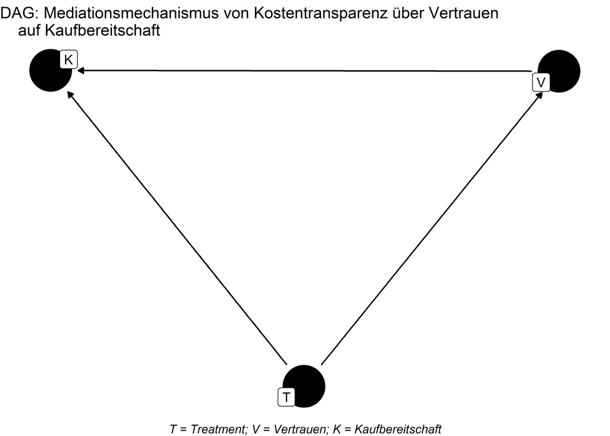

## Vertrauen als Mediator: Theoretische Fundierung und methodische Herausforderungen

**Begründung und Erklärung der DAG Struktur**

Der dargestellte Directed Acyclic Graph (DAG) modelliert den vermuteten kausalen Zusammenhang zwischen Kostentransparenz (`Treatment`,`T),`Vertrauen`(V) und`Kaufbereitschaft` (K).

Die Struktur basiert auf folgender Annahme:

- `Treatment` (T) beeinflusst das `Vertrauen` (V) der Teilnehmer:innen, da durch die Offenlegung von Produktionskosten die Transparenz steigt, was typischerweise zu einem höheren Vertrauen in den Anbieter führt.
- `Vertrauen` (V) wiederum beeinflusst die `Kaufbereitschaft` (K), da Konsument:innen eher bereit sind zu kaufen, wenn sie dem Unternehmen vertrauen.
- Zusätzlich gibt es auch einen direkten Effekt von `T` auf `K`, da `Kostentransparenz` auch unabhängig vom `Vertrauenszuwachs` einen direkten psychologischen Einfluss auf das `Kaufverhalten` haben kann (z.B. durch wahrgenommene Fairness oder moralisches Signal).

**Welche Annahmen müssen getroffen werden, damit Vertrauen tatsächlich als Mediator interpretiert werden kann?**

Damit `Vertrauen` (V) als Mediator zwischen `Treatment` (T) und `Kaufbereitschaft` (K) interpretiert werden kann, müssen folgende kausale Annahmen erfüllt sein:

1. *Kausalität in zeitlicher Reihenfolge*:

`Treatment` muss vor dem `Vertrauen` wirken, und `Vertrauen` wiederum vor der `Kaufentscheidung` entstehen.

2. *Keine unbeobachteten Confounder (Störvariablen)*:

Zwischen `T` und `V` dürfen keine unbeobachteten Variablen existieren, die beide beeinflussen (z.B. Informationsbedarf, allgemeine Transparenzsensibilität).

Zwischen `V` und `K` dürfen ebenfalls keine unbeobachteten Variablen stehen (z.B. Vorerfahrungen mit der Marke).

3. *Kein Rückwärtskausalitätsproblem* (keine Zyklik)

`Kaufbereitschaft` darf nicht rückwirkend das `Vertrauen` beeinflussen.

4. *Keine Interaktionen oder Moderatoren*, die den Zusammenhang zwischen `T` und `V` bzw. `V` und `K` stark verändern, sofern sie nicht kontrolliert wurden.
5. *Kein post-treatment bias*

Es dürfen keine Variablen in die Analyse eingehen, die durch das `Treatment` selbst beeinflusst wurden und gleichzeitig Einfluss auf `Vertrauen` oder `Kaufbereitschaft` haben.

**Welche Verzerrungen oder Störfaktoren könnten den Mediator-Effekt beeinflussen – und wie?**

1. *Unbeobachtete Drittvariablen (Confounder)*:

generelles Misstrauen, Sozialisation, oder Persönlichkeitsmerkmale wie Skepsis könnten sowohl das Vertrauen als auch die Kaufbereitschaft beeinflussen und so den Mediator-Effekt verzerren.

2. *Messfehler beim Vertrauen* (V):

Wenn `Vertrauen` ungenau oder verzerrt gemessen wird (z.B. durch schlechte Skalen oder Missverständnisse), kann der Mediator-Effekt unterschätzt oder verfälscht werden.

3. *Selektionseffekte / Selbstselektion*:

Wenn bestimmte Personen systematisch mit höherem `Vertrauen` ins `Treatment` geraten (z.B. über ein demographisches Merkmal), wäre der beobachtete Effekt nicht mehr rein kausal.

4. *Soziale Erwünschtheit / Antworttendenzen*:

Teilnehmer:innen könnten bewusst höheres `Vertrauen` äußern, obwohl es nicht real vorhanden ist – insbesondere in der Treatmentgruppe mit moralischem Signal.

5. *Nichtkontrollierte Drittvariablen wie Einkommen, Bildung oder Geschlecht*

Diese könnten sowohl `Vertrauen` als auch `Kaufverhalten` beeinflussen. Werden sie nicht kontrolliert, droht eine Scheinkorrelation zwischen `T`, `V` und `K`.

**Fazit**

Alles in allem lässt sich festhalten, dass der dargestellte DAG ein plausibles Modell zur Untersuchung des vermuteten Mediationsmechanismus darstellt. Damit `Vertrauen` jedoch tatsächlich als Mediator interpretiert werden kann, sind strenge kausalanalytische Annahmen erforderlich – insbesondere hinsichtlich unbeobachteter Störfaktoren und der zeitlichen Abfolge der Variablen. Zudem zeigen mögliche Verzerrungsquellen, dass eine vorsichtige Interpretation der Ergebnisse notwendig ist. Eine sorgfältige Modellierung und gegebenenfalls zusätzliche Kontrollvariablen sind entscheidend, um den vermuteten indirekten Effekt von `Kostentransparenz` über `Vertrauen` auf `Kaufbereitschaft` belastbar nachzuweisen.

15. Führen Sie nun eine Regression durch, bei der Ihnen `trust` (Vertrauen) als abhängige Variable dient. Weiterhin soll ihnen `treatment` als erklärende Variable dienen. Erstellen sie eine weitere Regression, die zusätzlich noch für die folgenden Variablen kontrolliert: Alter, Einkommensniveau, Bildungsstufe und ob die Personen weiblich sind.

Stellen Sie die Regressionsergebnisse in einer Tabelle mit stargazer oder modelsummary dar!

Beschreiben und interpretieren Sie ihre Ergebnisse. Gehen Sie bei der Interpretation der Ergebnisse insbesondere auf folgende Fragen ein:

- Macht es ihrer Ansicht nach Sinn auf die zusätzlichen Variablen in Regression 2 zu kontrollieren? Worauf müssen Sie besonders achten?
- Was bedeutet ein signifikanter positiver Koeffizient für treatment in Bezug auf Vertrauen?
- Warum ist dieser Pfad (Treatment ➝ Trust) notwendig, damit eine Mediation überhaupt möglich ist?
- Überlegen Sie, ob andere Faktoren, die Sie möglicherweise nicht berücksichtigt haben, diesen Zusammenhang ebenfalls erklären könnten.

**Einfluss von Kostentransparenz auf Vertrauen**

|  | *Dependent variable:* |  |
| --- | --- | --- |
|  | Abhängige Variable: Vertrauen |  |
|  | Regression | Regression |
|  | (1) | (2) |
| Treatment | 0.473*** | 0.454*** |
|  | (0.112) | (0.113) |
| Alter |  | -0.001 |
|  |  | (0.005) |
| Einkommen |  | -0.021 |
|  |  | (0.024) |
| Bildung |  | 0.058 |
|  |  | (0.067) |
| Weiblich |  | 0.179 |
|  |  | (0.114) |
| Constant | 4.821*** | 4.716*** |
|  | (0.079) | (0.320) |
| Observations | 601 | 601 |
| R<sup>2</sup> | 0.029 | 0.035 |
| Adjusted R<sup>2</sup> | 0.027 | 0.027 |
| Residual Std. Error | 1.374 (df = 599) | 1.374 (df = 595) |
| F Statistic | 17.791*** (df = 1; 599) | 4.291*** (df = 5; 595) |
| *Note:* | p<0.1; p<0.05; p<0.01 |  |

## Analyse des Zusammenhangs zwischen Treatment und Vertrauen unter Kontrolle weiterer Einflussfaktoren

**Kontrolle zusätzlicher Variablen in Regression 2**

Die Aufnahme von Kontrollvariablen wie `Alter`, `Einkommen`, `Bildung` und `Geschlecht` im zweiten Regressionsmodell ist sinnvoll, da diese Merkmale theoretisch sowohl mit dem `Vertrauen` als auch mit der Wahrnehmung des `Treatments` zusammenhängen könnten. Wichtig ist dabei, dass es sich um sogenannte prä-treatment-Variablen handelt, also um Merkmale, die vor dem `Treatment` existieren und nicht durch dieses beeinflusst werden können. In dieser Analyse trifft das zu. Dadurch wird sichergestellt, dass keine Scheinkorrelation zwischen `Treatment` und `Vertrauen` durch systematische Unterschiede in der Stichprobe entsteht. Die Ergebnisse zeigen jedoch, dass keine der Kontrollvariablen einen signifikanten Effekt hat, was darauf hindeutet, dass die Wirkung des `Treatments` unabhängig von diesen Faktoren besteht.

**Bedeutung des Pfads Treatment ➝ Vertrauen für Mediation**

Der Pfad vom `Treatment` zum `Vertrauen` ist eine notwendige Bedingung für einen Mediationsmechanismus, bei dem `Vertrauen` die Wirkung des `Treatments` auf die `Kaufabsicht` vermittelt. Nur wenn das `Treatment` tatsächlich das Vertrauen beeinflusst, kann `Vertrauen` als vermittelnde Variable wirken. Wäre dieser Pfad nicht vorhanden oder nicht signifikant, gäbe es keinen indirekten Effekt über `Vertrauen`, und eine Mediation wäre ausgeschlossen. Die vorliegenden Ergebnisse belegen, dass dieser Pfad empirisch vorhanden ist, wodurch eine weitere Analyse zur Mediation gerechtfertigt ist.

**Mögliche unbeobachtete Einflussfaktoren**

Mögliche unbeachtete Einflussfaktoren wären persönliche Einstellungen zu Transparenz, generelles `Vertrauen` in Unternehmen oder eine positive Grundhaltung gegenüber nachhaltigen Marken. Personen mit solchen Merkmalen könnten unabhängig vom Treatment stärkeres `Vertrauen` zeigen und zugleich empfänglicher auf die transparente Kostenstruktur reagieren. Wenn diese Faktoren nicht im Modell kontrolliert werden, kann der beobachtete Effekt des `Treatments` auf `Vertrauen` teilweise auf vorbestehende Unterschiede zurückgehen und damit überschätzt sein.

16. Nachdem Sie nun den Effekt des Treatments auf das Vertrauen geschätzt und ausgewertet haben, sollen Sie nun testen, ob das Vertrauen als Mediator zwischen Treatment und Kaufabsicht wirkt.

Führen Sie eine Regression durch, bei der Ihnen die Kaufbereitschaft als abhängige Variable dient. Weiterhin sollen die erklärende Variablen nun `treatment`, sowie das Vertrauen (`trust`) umfassen. Erstellen sie eine weitere Regression, die zusätzlich noch auf Alter, Einkommensniveau, Bildungsstufe und ob die Personen weiblich sind, kontrolliert.

Stellen Sie die Regressionsergebnisse passend in einer Tabelle dar!

Beschreiben und interpretieren Sie ihre Ergebnisse. Gehen Sie bei der Interpretation der Ergebnisse insbesondere auf folgende Fragen ein:

- Was könnten Ihrer Ansicht nach Gründe sein, dass `treatment` jetzt nicht mehr signifkant ist? Woran könnt das im Detail liegen?
- Warum ist es wichtig, `trust` und `treatment` gemeinsam in einem Modell zu betrachten?
- Warum könnte `trust` eine “notwendige Bedingung” sein, damit Transparenz der Kostenstruktur zu höherer Kaufbereitschaft führt?

**Regression zur Mediation: Einfluss von Vertrauen auf Kaufabsicht**

|  | *Dependent variable:* |  |
| --- | --- | --- |
|  | Abhängige Variable: Kaufbereitschaft |  |
|  | Regression | Regression |
|  | (1) | (2) |
| Treatment | 0.148 | 0.129 |
|  | (0.140) | (0.140) |
| Vertrauen | 0.813*** | 0.818*** |
|  | (0.050) | (0.050) |
| Alter |  | -0.013** |
|  |  | (0.006) |
| Einkommen |  | 0.041 |
|  |  | (0.030) |
| Bildung |  | 0.055 |
|  |  | (0.082) |
| Weiblich |  | -0.148 |
|  |  | (0.140) |
| Constant | -0.178 | -0.155 |
|  | (0.260) | (0.457) |
| Observations | 601 | 601 |
| R<sup>2</sup> | 0.317 | 0.327 |
| Adjusted R<sup>2</sup> | 0.315 | 0.320 |
| Residual Std. Error | 1.685 (df = 598) | 1.679 (df = 594) |
| F Statistic | 139.008*** (df = 2; 598) | 48.027*** (df = 6; 594) |
| *Note:* | p<0.1; p<0.05; p<0.01 |  |

## Mediationseffekt von Vertrauen in der Beziehung zwischen Transparenz und Kaufbereitschaft

**Bedeutung der gleichzeitigen Modellierung von trust und treatment**

Die gleichzeitige Berücksichtigung von `treatment` und `trust` ist entscheidend, um zwischen direkten und indirekten Effekten zu unterscheiden. Nur wenn beide Variablen im selben Modell enthalten sind, lässt sich erkennen, ob `trust` den Effekt des `Treatments` vermittelt. Wird nur `treatment` betrachtet, misst man einen Gesamteffekt, der nicht zwischen direktem und vermittelt durch `Vertrauen` laufendem Einfluss unterscheidet. Die gleichzeitige Modellierung ermöglicht daher eine präzisere kausale Interpretation und bildet die psychologischen Prozesse im Experiment realistischer ab.

**Vertrauen als notwendige Bedingung für Wirkung von Transparenz**

In den vorangegangenen Modellen wurde untersucht, ob das Treatment (Kostentransparenz) das Vertrauen in das Unternehmen beeinflusst und ob Vertrauen wiederum mit der Kaufabsicht zusammenhängt.

17. Bewerten Sie das experimentelle Design der Studie 2. Gehen Sie dabei auch darauf ein, inwiefern Ihre Ergebnisse aus Aufgabe 13 bis 16 das theoretische Verständnis von Vertrauensbildung in der Konsumentenpsychologie bestätigt oder infrage stellt. Welche Stärken und Schwächen sehen Sie bezüglich der internen Validität und der Kausalitätsaussagen? Diskutieren Sie zudem kurz, inwiefern die Ergebnisse auf andere Bevölkerungsgruppen oder kulturelle Kontexte übertragbar sind.

*Hinweis:* Informationen zum Verständnis der Vertrauensbildung in der Konsumentenpsychologie können Sie [in dem folgenden Artikel](https://www.shs-conferences.org/articles/shsconf/pdf/2021/26/shsconf_appsconf2021_03019.pdf) auf Seite 2 bis 5 nachlesen.

## Bewertung des experimentellen Designs und der theoretischen Implikationen von Experiment 2

Das experimentelle Design von Studie 2, das untersucht, ob Kostentransparenz die Kaufabsicht über Vertrauen als Mediator beeinflusst, ist robust, weist jedoch einige Schwächen auf. In dem Experiment wurden 601 Teilnehmende zufällig entweder einer Kontrollgruppe, die nur Standardproduktinformationen einer fiktiven Schokoladentafel erhielt, oder einer Treatmentgruppe, die zusätzlich eine Kostenaufstellung sah, zugeteilt. Vertrauen und Kaufbereitschaft wurden mittels Fragebögen erfasst, und die Analyse nutzte Regressionsmodelle, um direkte und vermittelte Effekte zu prüfen.

**Stärken des Experiments**

- Eine Stärke des Designs ist die *Randomisierung*, die systematische Verzerrungen minimiert, wie die Balancing-Tabelle zeigt, die vergleichbare demografische Merkmale wie `Geschlecht`, `Einkommen` und `Bildung` zwischen den Gruppen bestätigt.
- Die *Mediationsanalyse* ermöglicht zudem ein tieferes Verständnis des psychologischen Mechanismus, da die Ergebnisse belegen, dass `Vertrauen` ein zentraler Mediator ist, was mit der Theorie übereinstimmt, dass `Transparenz` als Signal für Ehrlichkeit `Vertrauen` fördert.
- Das *realitätsnahe Szenario* mit der Schokoladentafel erhöht die ökologische Validität, und die statistische Kontrolle für Confounder wie `Alter` oder `Geschlecht` verbessert die Präzision der Schätzungen.

**Schwächen des Experiments**

- Die *künstliche Laborumgebung* mit hypothetischen Entscheidungen ohne reale finanzielle Konsequenzen könnte vom tatsächlichen Kaufverhalten abweichen, da Teilnehmende keine tatsächlichen Kosten tragen. Zudem ist die Erhebung von `Vertrauen` und `Kaufbereitschaft` per Selbstauskunft anfällig für Verzerrungen durch soziale Erwünschtheit, da Teilnehmende möglicherweise Antworten geben, die sie als gesellschaftlich akzeptabel wahrnehmen.
- Ein leichter *Randomisierungsfehler* zeigt sich in einem signifikanten Altersunterschied zwischen den Gruppen, der, obwohl kontrolliert, die Generalisierbarkeit leicht beeinträchtigen könnte.

**Theoretische Implikationen**

Die Ergebnisse aus Aufgabe 13 bis 16 bestätigen weitgehend das theoretische Verständnis der Vertrauensbildung in der Konsumentenpsychologie, wie es im Artikel aus den SHS Web of Conferences (S. 2–5) beschrieben wird, stellen es jedoch teilweise infrage. Aufgabe 15 zeigt, dass `Kostentransparenz` das `Vertrauen` signifikant erhöht (β=0.454, p<0.001), was die `Kaufabsicht` vermittelt, wie Aufgabe 16 belegt (`trust` β=0.818, p<0.001). Der direkte Effekt von `Transparenz` auf die `Kaufabsicht` verschwindet, wenn `Vertrauen` kontrolliert wird, was einen starken Mediationsmechanismus bestätigt. Dies unterstützt die Theorie, dass `Transparenz` als Signal für Ehrlichkeit `Vertrauen` fördert, wie von White (2005) und Sirdeshmukh et al. (2002) postuliert, und unterstreicht die zentrale Rolle von Vertrauen in der Konsumentenpsychologie. Aufgabe 16 untermauert die Robustheit dieser Ergebnisse, da die Mediationsanalyse auch bei Hinzufügung von Kontrollvariablen konsistent bleibt, was die theoretische Fundierung des Effekts von `Transparenz` auf `Vertrauen` stärkt. Allerdings stellt das Experiment die Theorie infrage, da es keine negativen Szenarien wie unrealistisch hohe Margen berücksichtigt, die laut Artikel Vertrauen schnell zerstören könnten. Ohne solche Szenarien könnte der Effekt von `Transparenz` überschätzt werden, da reale Konsumentscheidungen oft durch solche negativen Signale beeinflusst werden.

**Interne Validität und Kausalitätsaussagen**

Die interne Validität des Experiments ist stark. Die Randomisierung und die Kontrolle für demografische Variablen wie `Alter, Geschlecht, Einkommen und Bildung` minimieren Confounding, und die konsistenten Ergebnisse der Mediationsanalyse (Aufgabe 16) unterstützen die Kausalität des Effekts von `Kostentransparenz` auf `Vertrauen` und `Kaufbereitschaft`. Die Analyse erfüllt die Voraussetzungen für Kausalität: `Transparenz` beeinflusst `Vertrauen` (Aufgabe 15), `Vertrauen` beeinflusst die `Kaufabsicht`, und der direkte Effekt von `Transparenz` schwindet, wenn `Vertrauen` kontrolliert wird. Dennoch gibt es Einschränkungen. Der Altersunterschied zwischen den Gruppen könnte eine leichte Verzerrung darstellen, obwohl er statistisch kontrolliert wurde. Zudem könnten unbeobachtete Mediatoren wie wahrgenommene Fairness oder Markenwahrnehmung den Effekt teilweise erklären, was die Kausalitätsaussagen einschränkt. Ohne diese zusätzlichen Faktoren bleibt unklar, ob Vertrauen der einzige oder primäre Mechanismus ist.

**Übertragbarkeit und Generalisierbarkeit**

Die Übertragbarkeit der Ergebnisse auf andere Bevölkerungsgruppen und kulturelle Kontexte ist begrenzt. Die US-basierte MTurk-Stichprobe ist nicht repräsentativ, und kulturelle Unterschiede könnten die Wahrnehmung von `Transparenz` beeinflussen. Der Artikel betont, dass `Vertrauen` kulturell geprägt ist (vgl. Czakó, 2011), und in kollektivistischen Kulturen wie in Asien könnte `Transparenz` als unüblich oder misstrauenerregend wahrgenommen werden. Jüngere Teilnehmer in der Treatmentgruppe könnten offener für `Transparenz` sein, was die Ergebnisse für ältere oder weniger technikaffine Gruppen einschränkt. Die fiktive Marke „Cocoa Passion“ ist kontextabhängig, und in realen Märkten könnte Markenloyalität den Effekt von Transparenz abschwächen. Dennoch ist die grundlegende Psychologie der Vertrauensbildung universell anwendbar, besonders in westlichen, individualistischen Kontexten, wo Transparenz positiv bewertet wird. Produkte mit niedrigem Involvement wie Schokolade dürften in ähnlichen Kontexten vergleichbare Effekte zeigen. Für eine breitere Anwendung wären jedoch Studien in diverseren kulturellen und demografischen Kontexten erforderlich, um die Robustheit der Ergebnisse zu bestätigen.

# Zusatzaufgabe

Zu Beginn des Projektes hatten wir erwähnt, dass die Experimente, welche im Projekt durchgeführt wurden, auf Grund eines Missgeschicks in der Online-Darstellung von unterschiedlichen Produkten zustande kam. Hier wurden von einem privat geführten Online-Händler Geldbörsen in fünf Farbvarianten angeboten, wobei beabsichtigt war, allen Farben eine einheitliche Kostentransparenz-Infografik zuzuordnen. Aufgrund eines Versehens wurde die Infografik jedoch nur bei drei Farben implementiert. Dieses zufällige Ereignis führte zu einer klaren Trennung zwischen den Produkten mit dieser und ohne diese Infografik. Das dadurch entstandene natürliche Experiment sollen Sie sich in der Zusatzaufgabe näher anschauen.

18. Lesen Sie sich den nachfolgenden Text zum Aufbau des natürlichen Experiments innerhalb dieses Papers durch und beantworten anschließend nachfolgende Fragen:

On December 2, 2013, a privately held online retailer launched a holiday gift shop with a single email to its mailing list, promoting a leather wallet offered in five colors (burgundy, black, grey, bone, and tan) and priced at $115.00. Later, at the end of January, to boost post-holiday sales, the retailer decided to add a cost transparency infographic to the online product detail pages for each of the wallet’s five color combinations. The retailer’s intention was to use the same infographic for all wallets since they differed only in color.

However, due to an inadvertent mistake, the infographic was not introduced for two of the wallet colors (bone and tan). Consequently, the cost transparency information was implemented for only three of the five wallet colors (burgundy, black, and grey) over a period of five weeks. This error created a natural experiment, enabling us to test the impact of cost transparency on wallet sales.

Therefore we have the following procedure:

- Operationalization of Cost Transparency: The infographic presented the total cost to produce the wallet, breaking it down into its specific components, namely: leather (14.68 US-Dollar), construction (38.56 US-Dollar), duties (4.26 US-Dollar), and transportation (1.00 US-Dollar). In addition, it included benchmark information indicating that the wallet had a 1.9x markup, in contrast to a 6x markup charged by a competitor. Because wallet colors serve as the basis for treatment assignment, the natural experiment compares “cost transparent” wallets (burgundy, black, and grey) to “non-transparent” wallets (bone and tan).
- Identification Strategy: We use a difference-in-differences approach to compare the daily sales between the treatment (cost transparency) and control (no cost transparency) groups before versus after the introduction of the infographic. By doing so, the design isolates the causal effect of cost transparency on the daily count of wallets sold for each color.
- Control Variables: Given that the cost transparency treatment was implemented by wallet color, and with only five available colors, it was necessary to control for potential confounders. For instance, we include a proxy for time-varying color popularity - the number of page views each wallet color received - and a proxy for time-varying inventory levels.

Beantworten Sie nun die folgenden Fragen in Bezug auf den vorherigen Text:

- Wie ist das natürliche Experiment aufgebaut, und warum wird es als solches klassifiziert?
- Welche Rolle spielt das zufällige Versäumnis, die Infografik bei zwei der fünf Farbvarianten einzuführen, in der Experimentstruktur?
- Warum ist es notwendig, Variablen wie Seitenaufrufe und Lagerbestandsproxies in die Analyse einzubeziehen?
  - Welche potenziellen Verzerrungen könnten auftreten, wenn diese Kontrollvariablen nicht berücksichtigt werden?

## Analyse des natürlichen Experiments zur Wirkung von Kostentransparenz auf Wallet-Verkäufe

**Aufbau und Klassifikation des natürlichen Experiments**

Das natürliche Experiment basiert auf einem ungeplanten Fehler: Die Einführung der Kostentransparenz-Infografik erfolgte nur bei drei der fünf verfügbaren Wallet-Farben (burgundy, black und grey), während zwei Farben (bone und tan) unbeabsichtigt unbehandelt blieben. Diese zufällige Variation in der Behandlung erlaubt einen quasi-experimentellen Vergleich zwischen einer Behandlungsgruppe (mit Transparenz) und einer Kontrollgruppe (ohne Transparenz), obwohl keine formale Randomisierung stattfand. Das Ereignis wird deshalb als natürliches Experiment klassifiziert, weil die Zuweisung zur Treatment- oder Kontrollgruppe nicht vom Forscher, sondern durch einen operativen Zufall bedingt war, wodurch eine exogene Variation entsteht, die sich zur Kausalanalyse eignet.

**Bedeutung des zufälligen Versäumnisses bei zwei Farben**

Das zufällige Versäumnis, die Transparenzinfografik bei zwei Wallet-Farben zu implementieren, ist zentral für die Validität des Designs. Dadurch entsteht eine natürliche Vergleichsgruppe, bei der – unter der Annahme ähnlicher Ausgangsbedingungen – alle Unterschiede in der Verkaufsentwicklung auf die Einführung der Infografik zurückgeführt werden können. Das Versäumnis wirkt somit wie eine quasi-zufällige Zuweisung zur Kontrollgruppe, was die internen Validitätsbedenken reduziert, die typischerweise bei nicht-randomisierten Designs bestehen.

**Notwendigkeit von Kontrollvariablen (Seitenaufrufe & Lagerbestand)**

Da die Zuweisung zum Treatment über die Farbvariante erfolgt und Farben unterschiedliche Beliebtheiten oder Lagerbestände haben können, ist es notwendig, zeitlich variable Störfaktoren zu kontrollieren:

Seitenaufrufe pro Farbe dienen als Proxy für Nachfrage und Popularität, da ein Anstieg der Page Views unabhängig vom Treatment zu höheren Verkäufen führen könnte.

Lagerbestände pro Farbe wirken als Angebotsbeschränkung: Selbst bei hoher Nachfrage könnten Farben mit niedrigem Bestand weniger verkauft werden.

Würde man diese Kontrollvariablen weglassen, könnten systematische Unterschiede zwischen Farben die Ergebnisse verzerren. Beispielsweise könnte eine Wallet-Farbe mit Infografik (z.B. burgundy) zufällig auch besonders beliebt sein oder öfter angezeigt werden. In dem Fall würde man fälschlicherweise einen Effekt der Kostentransparenz messen, der in Wirklichkeit auf eine höhere Grundnachfrage zurückgeht. Die Kontrolle dieser Variablen ist daher notwendig, um den kausalen Effekt der Infografik auf den Verkauf isoliert messen zu können.

19. Lesen Sie weiterhin das Kapitel [“Difference-in-Differences” in Huntington-Klein (2021)](https://theeffectbook.net/ch-DifferenceinDifference.html), speziell Kapitel 18.1 und 18.2 und beantworten Sie die folgenden Fragen dazu:

Kann eine Difference-in-Differences-Regression helfen, den kausalen Effekt der Kostentransparenz auf die Verkaufszahlen zu identifizieren?

Gehen Sie bei der Beantwortung dieser Frage insbesondere auf die nachfolgenden Punkte ein:

- Welche Art von Variation nutzt eine DiD-Regression in diesem Fall zur Identifikation des Effekts?
- Welche Voraussetzung(en) müssen erfüllt sein, damit DiD eine gültige Kausalschätzung liefert?
  - Was bedeutet die „Parallel Trends“-Annahme in diesem Kontext?
  - Warum reicht es nicht aus, nur zu vergleichen, wie sich die Verkaufszahlen nach der Einführung verändert haben?
- Basierend auf dem Kontext des Buchkapitels zu Difference-in-Differences (DiD) und den Informationen aus `Aufgabe 18`, formulieren Sie bitte die **Regressionsgleichung**, mit der der Effekt der Kostentransparenzmaßnahme mithilfe eines DiD-Ansatzes untersucht werden kann.
  - Definieren Sie dabei klar alle verwendeten Variablen.
  - Stellen Sie die Regressionsgleichung in mathematischer Form dar.
  - Beschreiben und erklären Sie das von Ihnen aufgestellte Modell.

## Analyse der Anwendung einer Difference-in-Differences-Regression zur Identifikation des Kausaleffekts von Kostentransparenz

Das natürliche Experiment, bei dem eine Kostentransparenz-Infografik versehentlich nur für drei von fünf Wallet-Farben (burgundy, black, grey) eingeführt wurde, ermöglicht die Untersuchung des Kausaleffekts auf Verkaufszahlen mit einer Difference-in-Differences (DiD)-Regression. Im Folgenden wird erläutert, wie DiD diesen Effekt identifiziert, welche Variation genutzt wird, welche Voraussetzungen gelten, was die „Parallel Trends“-Annahme bedeutet, warum ein einfacher Vergleich unzureichend ist und die Regressionsgleichung formuliert wird.

**Kann DiD den Kausaleffekt identifizieren?**

Ja, eine DiD-Regression kann den Kausaleffekt der Kostentransparenz auf Verkaufszahlen isolieren, indem sie die Verkaufsentwicklung der behandelten (transparente) und unbehandelten (nicht-transparente) Farben vor und nach der Infografik vergleicht, unter Berücksichtigung zeitlicher Trends und gruppenspezifischer Unterschiede.

**Genutzte Variation**

DiD nutzt die zeitliche und gruppenspezifische Variation durch die Einführung der Infografik bei drei Farben (burgundy, black, grey) Ende Januar. Die zufällige Nicht-Einführung bei bone und tan schafft eine quasi-zufällige Kontrollgruppe. Laut Huntington-Klein (2021) vergleicht DiD die Veränderung der Verkaufszahlen in der Behandlungsgruppe mit der der Kontrollgruppe, um den Behandlungseffekt zu isolieren.

**Voraussetzungen für Kausalschätzung**

Für eine valide DiD-Schätzung müssen laut Huntington-Klein (2021) folgende Voraussetzungen erfüllt sein:

- *Parallel Trends Annahme*: Die Verkaufszahlen der behandelten und unbehandelten Farben hätten ohne Behandlung ähnliche Trends im Pre-Treatment-Zeitraum. Dies bedeutet, dass die Verkaufszahlen von burgundy, black und grey ohne Infografik ähnlich wie die von bone und tan verlaufen wären. Eine Verletzung dieser Annahme, z. B. durch farbspezifische saisonale Trends, würde die Ergebnisse verzerren.
- *Keine parallelen Behandlungen*: Keine anderen Ereignisse (z. B. farbspezifische Werbung) dürfen die Verkaufszahlen während des Behandlungszeitraums unterschiedlich beeinflussen.
- *Stabile Gruppen*: Die Farbzuweisung zu Behandlungs- und Kontrollgruppe bleibt konstant.
- *Kontrolle für Confounder*: Störfaktoren wie Seitenaufrufe und Lagerbestände müssen kontrolliert werden.

**Parallel Trends Annahme**

Die Annahme impliziert, dass die Kontrollgruppe (bone, tan) den kontrafaktischen Verlauf der Behandlungsgruppe ohne Transparenz widerspiegelt. Sie ist nicht direkt überprüfbar, kann aber durch Pre-Treatment-Trends validiert werden, z. B. durch Vergleich der Verkaufszahlen vor der Infografik.

**Warum ein einfacher Vergleich unzureichend ist**

Ein Vergleich der Verkaufszahlen nach der Einführung ignoriert zeitliche Trends (z. B. saisonale Nachfrage) und farbspezifische Unterschiede, was zu Verzerrungen führt. DiD löst dies, indem es die Veränderung in der Kontrollgruppe als Baseline für den kontrafaktischen Verlauf der Behandlungsgruppe nutzt.

**Regressionsgleichung**

$Y_{it} = \beta_0 + \beta_1 Treated_i + \beta_2 Post_t + \beta_3 (Treated_i \times Post_t) + \gamma_1 Views_{it} + \gamma_2 Inventory_{it} + \epsilon_{it}$

*Variablen*:

- $Y_{it}$: Tägliche Verkaufszahlen für Farbe $i$ an Tag $t$.
- $Treated_i$: Dummy, 1 für transparente Farben (burgundy, black, grey), 0 sonst (bone, tan).
- $Post_t$: Dummy, 1 nach Infografik-Einführung, 0 davor.
- $Treated_i \times Post_t$: Interaktion, misst den DiD-Effekt.
- $Views_{it}$: Seitenaufrufe für Farbe $i$ an Tag $t$.
- $Inventory_{it}$: Lagerbestand für Farbe $i$ an Tag $t$.
- $\beta_0$: Konstante, Verkaufszahlen der Kontrollgruppe vor Behandlung.
- $\beta_1$: Unterschied zwischen Gruppen vor Behandlung.
- $\beta_2$: Zeitlicher Trend in der Kontrollgruppe.
- $\beta_3$: DiD-Effekt der Kostentransparenz.
- $\gamma_1, \gamma_2$: Koeffizienten für Kontrollvariablen.
- $\epsilon_{it}$: Fehlerterm.

Das Modell schätzt den Kausaleffekt der Kostentransparenz, wobei $\beta_3$ die zusätzliche Veränderung der Verkaufszahlen der behandelten Farben nach der Infografik im Vergleich zur Kontrollgruppe misst. $Treated_i$ und $Post_t$ kontrollieren gruppen- und zeitspezifische Unterschiede, während $Views_{it}$ und $Inventory_{it}$ Verzerrungen durch Popularität und Verfügbarkeit minimieren. Das Modell ist valide, wenn die Parallel Trends Annahme und andere Voraussetzungen erfüllt sind.

Damit ist DiD geeignet den Kausaleffekt der Kostentransparenz zu identifizieren, indem es die exogene Variation des natürlichen Experiments nutzt. Die Parallel Trends Annahme ist zentral und erfordert Validierung durch Pre-Treatment-Daten. Die Regressionsgleichung mit Kontrollvariablen minimiert Verzerrungen und liefert eine präzise Schätzung, sofern keine parallelen Behandlungen vorliegen.

20. Zum Abschluss des Projekts sollen Sie sich das oben beschriebene natürliche Experiment genauer anschauen. Lesen Sie hierzu die Daten (`Experiment3.csv`) in R ein. Nennen Sie den Datensatz `daten_exp3`. Erstellen Sie eine Variable `log_units`, die die logarithmierte Anzahl an verkauften Einheiten darstellt.

Erstellen Sie weiterhin eine passende Grafik, die die durchschnittliche Anzahl der verkauften Produkte je Treatment pro Woche abbildet. Fügen Sie weiterhin eine vertikale Linie für den 28. Januar 2014 in ihre Grafik ein, welche die Einführung der Kostentransparenz markiert.

Beschreiben und interpretieren Sie ihre Grafik. Gehen Sie insbesondere auf die Entwicklung der durchschnittlichen Verkaufszahlen in beiden Gruppen vor und nach dem 28. Januar ein. Gibt es visuelle Hinweise auf eine Wirkung der Kostentransparenz?

- Angenommen, beide Gruppen (Treatment und Kontrolle) zeigen vor der Einführung der Kostentransparenz einen gleich starken Anstieg der durchschnittlich verkauften Einheiten. Was würde das für die Interpretation der Maßnahme im Rahmen eines Difference-in-Differences-Ansatzes bedeuten?

*Hinweis:* Für die Ableitung der Wochen aus dem Datumsformat kann die Funktion `isoweek()` aus dem Paket `lubridate` verwendet werden.

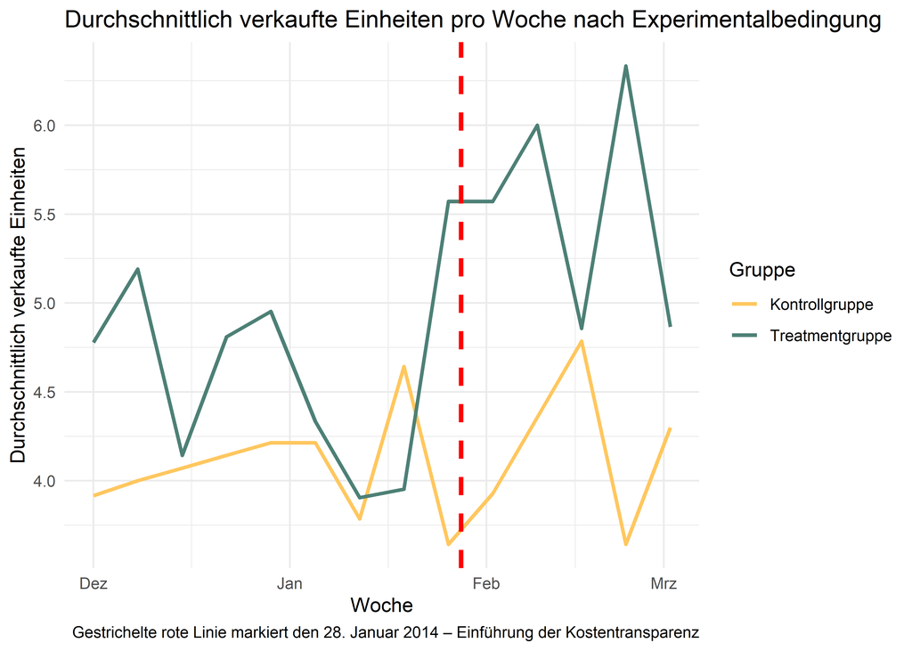

## Entwicklung der durchschnittlichen Verkaufszahlen und Wirkung der Kostentransparenz in Experiment 3

**Entwicklung vor und nach dem 28. Januar**

*Vor dem 28. Januar*:

Beide Gruppen zeigen im Zeitraum von Anfang Januar bis Mitte Januar ein vergleichbares Verlaufsmuster. Kurz *vor der Einführung der Kostentransparenz* steigt die Treatmentgruppe jedoch deutlich an – von einem Niveau um 4,0 auf über 5,5 Einheiten. Gleichzeitig sinkt die Kontrollgruppe stark ab, was zu einer zunehmenden Differenz zwischen den Gruppen führt.

**Interpretation im Rahmen eines Difference-in-Differences-Ansatzes**

*Annahme eines gleich starken Anstiegs vor der Einführung*

21. Erstellen Sie eine (mehrere) weitere passende Grafik(en), die die durchschnittlich verkauften Einheiten pro Tag in Treatment und Kontrolle vor und nach der Einführung der Kostentransparenz abbildet. Ergänzen Sie in ihrer Grafik die jeweiligen Standardfehler als Fehlerbalken. Beschreiben und interpretieren Sie ihre Grafik. Gehen Sie insbesondere auf die Unterschiede vor und nach der Einführung der Kostentransparenz ein.
- Inwiefern lassen sich daraus erste Hinweise auf einen möglichen Effekt des natürlichen Experiments erkennen?

*Hinweis:* Für die Erstellung der Grafik können Sie sich an Aufgabe 7 und 9 orientieren.

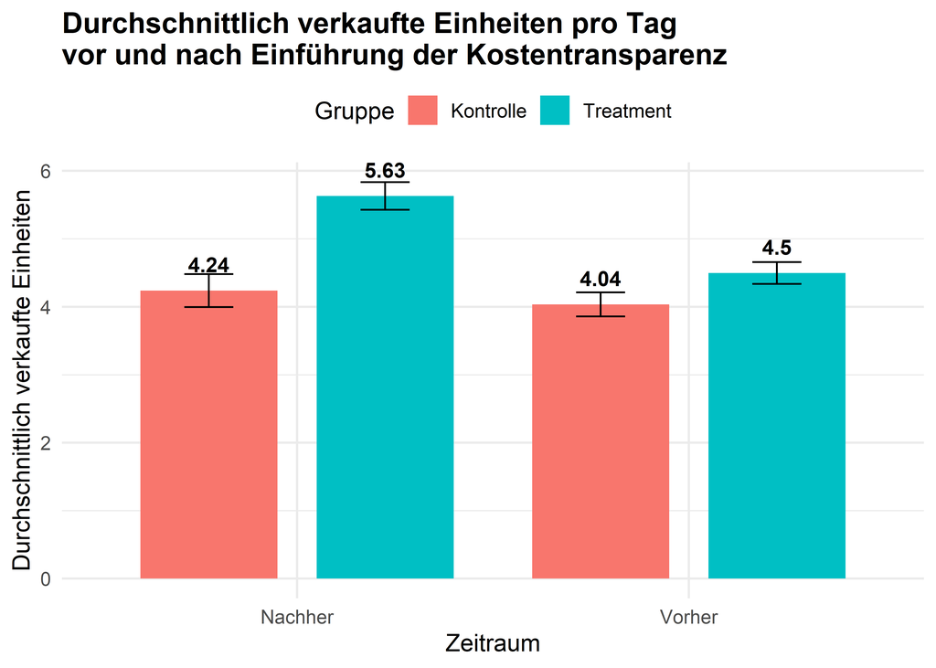

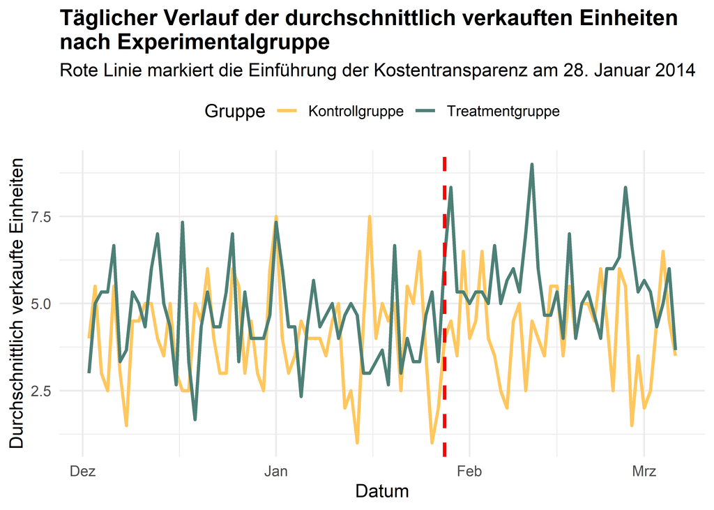

**Darstellung und Beschreibung der Grafiken**

In der ersten Grafik wurde der durchschnittliche Absatz pro Tag für die Kontrollgruppe (ohne Kostentransparenz) und die Treatmentgruppe (mit Kostentransparenz) jeweils vor und nach Einführung der Infografik am 28. Januar 2014 dargestellt. Die Balken zeigen die Mittelwerte, ergänzt durch Standardfehlerbalken, um die Streuung und Unsicherheit der Schätzung visuell abzubilden.

Zusätzlich wurde eine zweite Grafik erstellt, die den täglichen Verlauf der Verkaufszahlen für beide Gruppen über die Zeit hinweg darstellt. Die gestrichelte rote Linie markiert den Stichtag der Einführung der Kostentransparenz. Diese zeitlich aufgelöste Darstellung ermöglicht es, den Verkaufsverlauf vor und nach der Intervention genauer zu verfolgen.

**Entwicklung der Verkaufszahlen vor und nach Einführung der Kostentransparenz**

Die Ergebnisse zeigen, dass sich die Treatmentgruppe bereits vor der Einführung der Kostentransparenz leicht über dem Niveau der Kontrollgruppe bewegte. Dieser Unterschied war mit einem Mittelwert von ca. 4.50 Einheiten (Treatment) gegenüber 4.04 Einheiten (Kontrolle) aber relativ gering.

Nach Einführung der Kostentransparenz zeigt sich ein deutlich stärkerer Unterschied: Die durchschnittlich verkauften Einheiten pro Tag in der Treatmentgruppe steigen auf 5.63, während die Kontrollgruppe bei 4.24 Einheiten verbleibt. Damit ergibt sich eine Differenz von ca. 1.39 Einheiten, was auf einen potenziellen kausalen Effekt der Transparenzmaßnahme hindeutet.

**Erste Hinweise auf einen kausalen Effekt (im Sinne des natürlichen Experiments)**

In diesem Kontext kann die Differenz zwischen Treatment- und Kontrollgruppe nach der Einführung der Kostentransparenz als Hinweis auf einen positiven Effekt der Maßnahme interpretiert werden. Zwar sind visuelle Vergleiche noch keine formale Kausalschätzung, sie liefern jedoch – in Kombination mit der zufälligen Zuweisung durch das Missgeschick – eine starke Grundlage für eine DiD-Analyse, wie in Aufgabe 19 bereits beschrieben und vorbereitet.

**Fazit** Die beiden Grafiken liefern konsistente und deutliche Hinweise auf einen positiven Effekt der Kostentransparenz-Infografik auf die Verkaufszahlen der Wallets. Während die Verkaufszahlen der Kontrollgruppe weitgehend stabil blieben, stiegen sie in der Treatmentgruppe signifikant an. In Verbindung mit der zufälligen Implementierung der Infografik (natürliches Experiment) und der Anwendung des DiD-Ansatzes ergibt sich ein robuster erster Hinweis auf einen kausalen Zusammenhang zwischen Transparenz und gesteigerter Kaufaktivität.

Für eine abschließende Bewertung wäre eine formale Regressionsanalyse mit Interaktionsterm – wie in Aufgabe 19 beschrieben – erforderlich. Die hier präsentierte deskriptive Analyse legt jedoch bereits eine substanzielle Wirkung der Maßnahme nahe.

22. In der vorherigen Aufgabe haben Sie den Effekt von Kostentransparenz auf die Verkaufszahlen anhand eines deskriptiven Vergleichs untersucht. Dabei haben Sie die durchschnittlich täglich verkauften Einheiten je Treatment vor und nach der Einführung der Transparenzmaßnahme grafisch gegenübergestellt. In dieser Aufgabe sollen Sie diesen Effekt nun ökonometrisch genauer untersuchen, indem Sie den Difference-in-Differences Ansatz in einem Regressionsrahmen anwenden.

Untersuchen Sie den Effekt der Einführung von Kostentransparenz auf die Verkaufszahlen mithilfe einer Difference-in-Differences Regression. Verwenden Sie hierfür Beobachtungen an Werktagen, sowie am Wochenende (Montag bis Sonntag), mit positiven Verkaufszahlen.

Erstellen Sie insgesamt zwei Regressionsmodelle:

- Basismodell ohne Kontrollvariablen
- Modell mit Kontrolle für Wochentagseffekte

Stellen Sie die Ergebnisse anschaulich dar. Beschreiben und interpretieren Sie Ihre Ergebnisse. Gehen Sie insbesondere auf folgende Aspekte ein.

- Wie würden Sie die Größe des Effekts interpretieren, den Sie für `treated:post` erhalten haben?
- Welche Vorteile bringt es, log_units (logarithmierte Verkäufe) als abhängige Variable zu verwenden?
- Können Sie aus Ihrer Schätzung auf einen kausalen Effekt der Kostentransparenz schließen?
- Inwiefern hilft die Kontrolle für Wochentage dabei, Verzerrungen in der Schätzung zu vermeiden?
- Würden Sie auf Basis Ihrer Analyse eine Empfehlung zur Beibehaltung oder Ausweitung der Kostentransparenz geben?
- Worin könnten ihrer Ansicht nach Probleme liegen bei der Betrachtung eines natürlichen Experiments, die die Ergebnisse verzerren könnten?

*Hinweis 1:* Nutzen Sie für die Schätzung die `feols()`-Funktion aus dem fixest-Paket.

*Hinweis 2:* Nutzen Sie die logarithmierten täglichen Verkaufszahlen als abhängige Variable.

|  | Basismodell | Mit Wochentagskontrolle |
| --- | --- | --- |
| (Intercept) | 1.285*** | 1.292*** |
|  | (0.049) | (0.075) |
| treated | 0.105+ | 0.106+ |
|  | (0.063) | (0.063) |
| post | 0.066 | 0.064 |
|  | (0.077) | (0.077) |
| treated × post | 0.182+ | 0.182+ |
|  | (0.099) | (0.099) |
| factor(weekday)Donnerstag |  | -0.098 |
|  |  | (0.087) |
| factor(weekday)Freitag |  | 0.041 |
|  |  | (0.089) |
| factor(weekday)Mittwoch |  | 0.120 |
|  |  | (0.087) |
| factor(weekday)Montag |  | -0.004 |
|  |  | (0.088) |
| factor(weekday)Samstag |  | 0.005 |
|  |  | (0.089) |
| factor(weekday)Sonntag |  | -0.123 |
|  |  | (0.089) |
| Num.Obs. | 470 | 470 |
| R2 | 0.060 | 0.081 |
| RMSE | 0.51 | 0.51 |
| Std.Errors | IID | IID |

+ p < 0.1, * p < 0.05, ** p < 0.01, *** p < 0.001

**Zielsetzung und methodischer Rahmen**

Ziel der Analyse war es, den Effekt der Einführung einer Kostentransparenz-Infografik auf die Verkaufszahlen eines Produkts ökonometrisch zu untersuchen. Dazu wurde ein Difference-in-Differences (DiD)-Ansatz gewählt, der die Veränderung der Verkäufe in einer Behandlungsgruppe (Produkte mit Infografik) mit der in einer Kontrollgruppe (ohne Infografik) vergleicht – jeweils vor und nach der Einführung der Maßnahme. Es wurden zwei Modelle geschätzt:

ein Basismodell ohne Kontrollvariablen

ein erweitertes Modell mit Kontrolle für Wochentagseffekte.

In beiden Modellen wurde die logarithmierte Anzahl verkaufter Einheiten (log_units) als abhängige Variable verwendet.

**Interpretation des zentralen Effekts (treated × post)**

Der zentrale DiD-Koeffizient (treated × post) beträgt in beiden Modellen 0.182 und ist jeweils auf dem 10 %-Niveau signifikant (p < 0.1).

Dieser Koeffizient gibt den zusätzlichen Anstieg der logarithmierten Verkaufszahlen in der Treatmentgruppe nach Einführung der Transparenz an – relativ zur Kontrollgruppe. Da die abhängige Variable logarithmiert ist, lässt sich der Effekt wie folgt interpretieren:

exp(0.182)−1≈0.20=20% → Die Einführung der Kostentransparenz ist mit einem durchschnittlichen Anstieg der Verkäufe um etwa 20 % verbunden, relativ zur Kontrollgruppe und relativ zur Zeit davor.

**Bedeutung der Verwendung von log_units als abhängige Variable**

Die Verwendung der logarithmierten Verkaufszahlen bringt mehrere Vorteile mit sich:

Interpretierbarkeit in Prozent: Veränderungen lassen sich als prozentuale Effekte deuten, was ökonomisch oft intuitiver ist.

Reduktion von Heteroskedastizität: Da Verkaufszahlen typischerweise rechtsschief verteilt sind, hilft eine Log-Transformation, die Varianz zu stabilisieren.

Abmilderung extremer Ausreißer: Die Log-Transformation reduziert den Einfluss sehr großer Verkaufszahlen, was robuste Schätzungen unterstützt.

**Rolle der Wochentagskontrollen und deren Effekt**

Im erweiterten Modell wurden die einzelnen Wochentage als Faktoren (Dummy-Variablen) kontrolliert. Zwar zeigt keiner der Wochentagseffekte hohe Signifikanz, doch die Kontrolle sorgt dafür, dass systematische Unterschiede im Kaufverhalten je Wochentag (z. B. höhere Käufe am Wochenende oder zu Wochenbeginn) nicht fälschlich dem Treatmenteffekt zugeschrieben werden.

→ Die Stabilität des treated × post-Koeffizienten über beide Modelle hinweg spricht dafür, dass der Effekt robust ist – unabhängig davon, ob Wochentagseffekte berücksichtigt werden oder nicht.

**Kausale Aussagekraft und mögliche Verzerrungen**

Mögliche Verzerrungsquellen bleiben dennoch:

Unbeobachtete farbspezifische Trends (z. B. plötzliche Modevorlieben)

Unterschiede in der Sichtbarkeit auf der Website

Verfügbarkeit oder Lagerbestand, falls nicht vollständig kontrolliert

Dennoch spricht die Konstanz des Effekts über verschiedene Modellvarianten hinweg dafür, dass der gemessene Effekt tatsächlich auf die Infografik zurückzuführen ist.

**Fazit**

# Literatur

Mohan, B., Buell, R. W., & John, L. K. (2020). Lifting the veil: The benefits of cost transparency. Marketing Science, 39(6), 1105-1121. https://doi.org/10.1287/mksc.2019.1200

# Anhang

## Mediator

Im Rahmen von Mediationen ist der Mediator eine Variable, die den erklärenden Zusammenhang zwischen einer unabhängigen und einer abhängigen Variable vermittelt. Dabei wird untersucht, inwieweit der Einfluss der unabhängigen Variablen (z.B. Kostentransparenz) auf die abhängige Variable (z.B. Kaufabsicht) über einen vermittelnden Mechanismus - wie das Vertrauen der Kunden - erfolgt.

1. **Mediatoreffekt**: Der Mediatoren-Effekt, oft als ACME (Average Causal Mediation Effect) bezeichnet, beschreibt den indirekten Effekt, den die unabhängige Variable auf die abhängige Variable über den Mediator ausübt. Ist dieser Effekt signifikant, signalisiert dies, dass ein wesentlicher Teil des gesamten Einflusses über den vermittelnden Mechanismus läuft. Gleichzeitig kann ein nicht-signifikanter direkter Effekt (ADE - Average Direct Effect) darauf hindeuten, dass der Mediator den hauptsächlichen Erklärungsmechanismus darstellt.
2. **Funktion und Wirkung des Mediators**: Analog zum Konzept der signalgebenden Funktion bei Statussymbolen - deren Wert unter anderem von der Exklusivität und dem sozialen Kontext abhängt - fungiert der Mediator als vermittelnder Kanal, der erklärt, wie und warum der ursprüngliche Zusammenhang zwischen zwei Variablen zustande kommt. Der Mediator „überträgt“ quasi den Effekt der unabhängigen Variable auf die abhängige Variable. Dadurch kann in Modellen, in denen der direkte Zusammenhang zwischen der unabhängigen und der abhängigen Variable durch die Einbeziehung des Mediators verschwindet oder abgeschwächt wird, abgeleitet werden, dass der Mechanismus über den Mediator läuft. Dies ermöglicht ein tieferes Verständnis der zugrundeliegenden psychologischen Prozesse - etwa wie das Vertrauen der Kunden die Wirkung von Kostentransparenz auf deren Kaufabsicht vermittelt.

Zusammengefasst spielt der Mediator eine zentrale Rolle bei der Aufklärung der kausalen Mechanismen, indem er als vermittelnder Faktor zwischen Ursache und Wirkung identifiziert wird. Die signifikante Vermittlung über den Mediator zeigt, dass nicht allein das Vorhandensein von Kostentransparenz entscheidend ist, sondern auch, inwiefern diese Transparenz das Vertrauen stärkt - was wiederum maßgeblich die Kaufabsicht beeinflusst. So liefert die Mediationsanalyse wertvolle Einsichten, die über einfache bivariate Zusammenhänge hinausgehen und die Komplexität kausaler Mechanismen innerhalb von sozialen oder marktorientierten Prozessen sichtbar machen.

## Informationen zum Studiendesign des Experiments 1 und 2